# **Data Modeling**

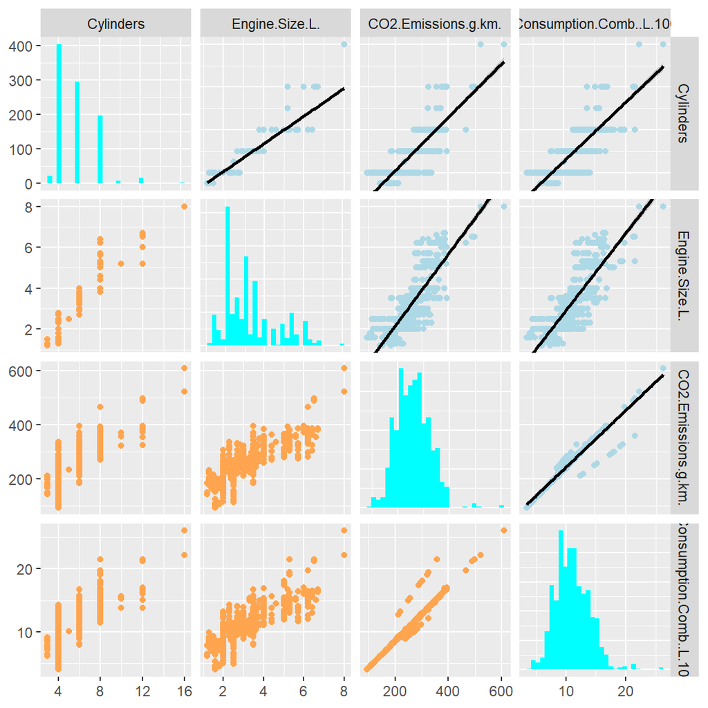

```r
library(ggplot2)


# Select only relevant numeric columns
selected_data <- Data_4[, c("Cylinders", "Engine.Size.L.", "CO2.Emissions.g.km." , "Fuel.Consumption.Comb..L.100.km..")]

# Create pairplot equivalent
ggpairs(selected_data,
        upper = list(continuous = wrap("smooth", color = "lightblue")),  # Regression lines
        lower = list(continuous = wrap("points", color = "tan1")),    # Scatterplot
        diag = list(continuous = wrap("barDiag", fill = "cyan")))    # Histogram in diagonal
```

In Polynomial regression, although the trend of data looks curvy. the method is similar to a combination of simple linear regression and multiple linear regression. Similar to linear regression means, it is dependent on single feature. However, when it says it behaves as multiple linear regression, it is because that single feature is converted to its quadratic, cubic, quartic and so on, and it can go on and on to infinite degrees and then it is treated as MLR. In essence, the relationship between the independent variable x and the dependent variable y is modeled as an nth degree polynomial in x.

```r
# Split the data into training and testing samples
set.seed(1023)

#split the data into two parts 70-30 split
DataSplit<-createDataPartition(y = Data_4$CO2.Emissions.g.km., p = 0.7, list = FALSE)

#creating the train and test data set
Case4_data_train<-Data_4[DataSplit,]
Case4_data_test<-Data_4[-DataSplit,]

# You need to verify, do I have really 70% or close
n <- length(Data_4$CO2.Emissions.g.km.)
Seventy_percent_sample_size<-round(0.7*n,0)
# Result of the R-function
R_function<-length(Case4_data_train$CO2.Emissions.g.km.)

# Compare side by side
cbind(Seventy_percent_sample_size,R_function)
```

```
##      Seventy_percent_sample_size R_function
## [1,]                         662        663
```

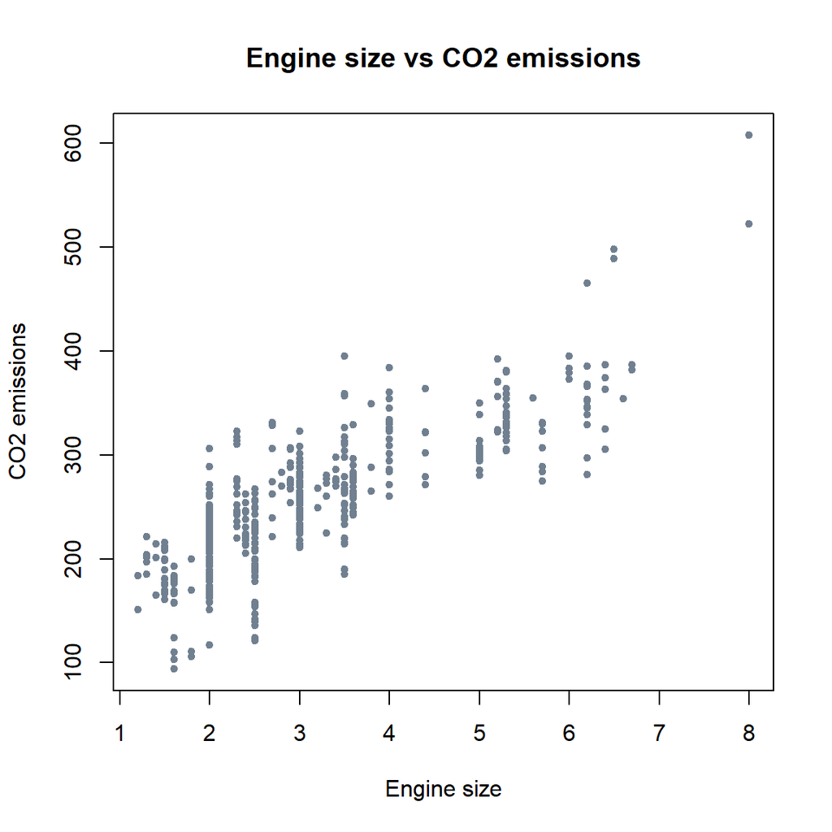

```r
# Scatter plot with regression line
plot(Case4_data_train$Engine.Size.L., Case4_data_train$CO2.Emissions.g.km.,
     main = "Engine size vs CO2 emissions",
     xlab = "Engine size", ylab = "CO2 emissions",
     pch = 20,
     col = "slategray",
     xlim = range(Case4_data_train$Engine.Size.L.),
     ylim = range(Case4_data_train$CO2.Emissions.g.km.))
```

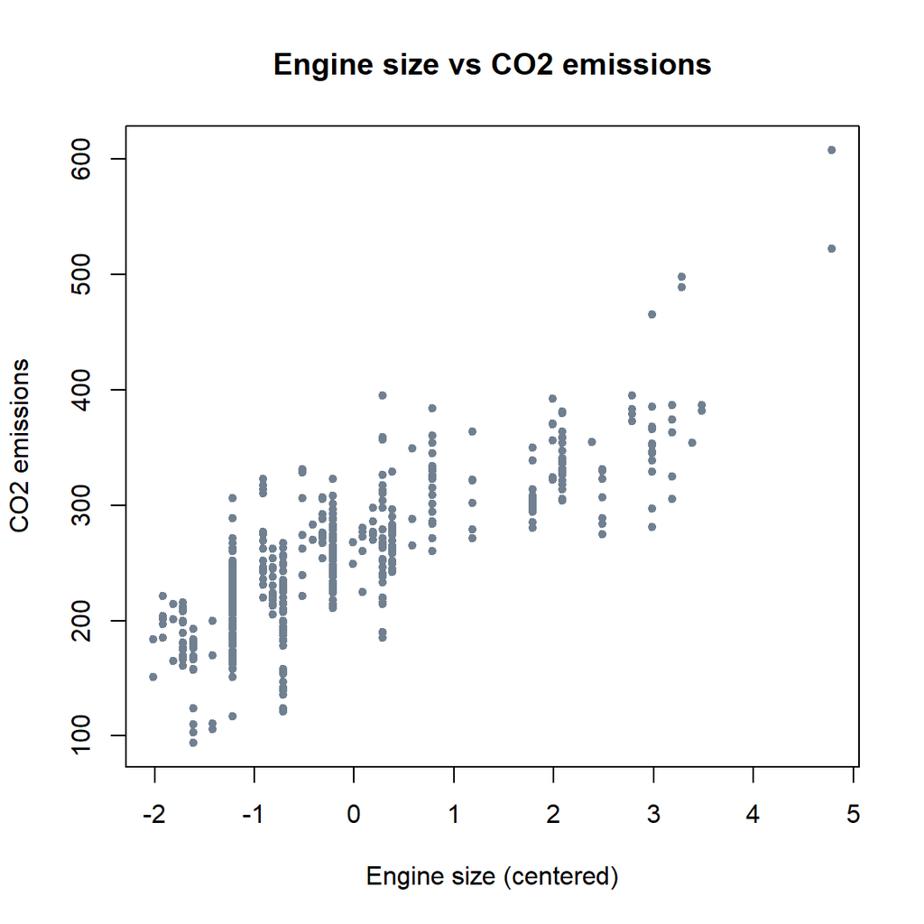

```r
#Let's center the variable

Case4_data_train$Engine.Size.L.centered<-(Case4_data_train$Engine.Size.L.-mean(Case4_data_train$Engine.Size.L.))
Case4_data_train$Engine.Size.L.centered.sqr <- Case4_data_train$Engine.Size.L.centered^2
Case4_data_train$Engine.Size.L.centered.cub <- Case4_data_train$Engine.Size.L.centered^3

# Scatter plot with regression line centered
plot(Case4_data_train$Engine.Size.L.centered, Case4_data_train$CO2.Emissions.g.km.,
     main = "Engine size vs CO2 emissions",
     xlab = "Engine size (centered)", ylab = "CO2 emissions",
     pch = 20,
     col = "slategray",
     xlim = range(Case4_data_train$Engine.Size.L.centered),
     ylim = range(Case4_data_train$CO2.Emissions.g.km.))
```

### Creating a model

```r
model_4.1 <- lm(CO2.Emissions.g.km. ~ Engine.Size.L.centered + Engine.Size.L.centered.sqr, data = Case4_data_train)
summary(model_4.1)
```

```
##
## Call:
## lm(formula = CO2.Emissions.g.km. ~ Engine.Size.L.centered + Engine.Size.L.centered.sqr,
##     data = Case4_data_train)
##
## Residuals:
##     Min      1Q  Median      3Q     Max
## -111.53  -22.09    0.49   21.40  196.06
##
## Coefficients:
##                            Estimate Std. Error t value Pr(>|t|)
## (Intercept)                262.3379     1.9228 136.438  < 2e-16 ***
## Engine.Size.L.centered      40.3694     1.3620  29.640  < 2e-16 ***
## Engine.Size.L.centered.sqr  -1.9032     0.6909  -2.754  0.00604 **
## ---
## Signif. codes:  0 '***' 0.001 '**' 0.01 '*' 0.05 '.' 0.1 ' ' 1
##
## Residual standard error: 36.19 on 660 degrees of freedom
## Multiple R-squared:  0.6776, Adjusted R-squared:  0.6766
## F-statistic: 693.5 on 2 and 660 DF,  p-value: < 2.2e-16
```

```r
# Scatter plot with regression line centered
plot(Case4_data_train$Engine.Size.L.centered, Case4_data_train$CO2.Emissions.g.km.,
     main = "Engine size vs CO2 emissions",
     xlab = "Engine size (centered)", ylab = "CO2 emissions",
     pch = 20,
     col = "slategray",
     xlim = range(Case4_data_train$Engine.Size.L.centered),
     ylim = range(Case4_data_train$CO2.Emissions.g.km.))

# Define x-values for prediction (100 points)
x_seq <- seq(min(Case4_data_train$Engine.Size.L.centered),
             max(Case4_data_train$Engine.Size.L.centered), length.out = 100)

# Predict y-values using the model
y_pred <- predict(model_4.1,
                  newdata = data.frame(Engine.Size.L.centered = x_seq,
                                       Engine.Size.L.centered.sqr = x_seq^2))

# Print lengths to verify they match
print(length(x_seq))   # Should be 100
```

```
## [1] 100
```

```r
print(length(y_pred))  # Should be 100
```

```
## [1] 100
```

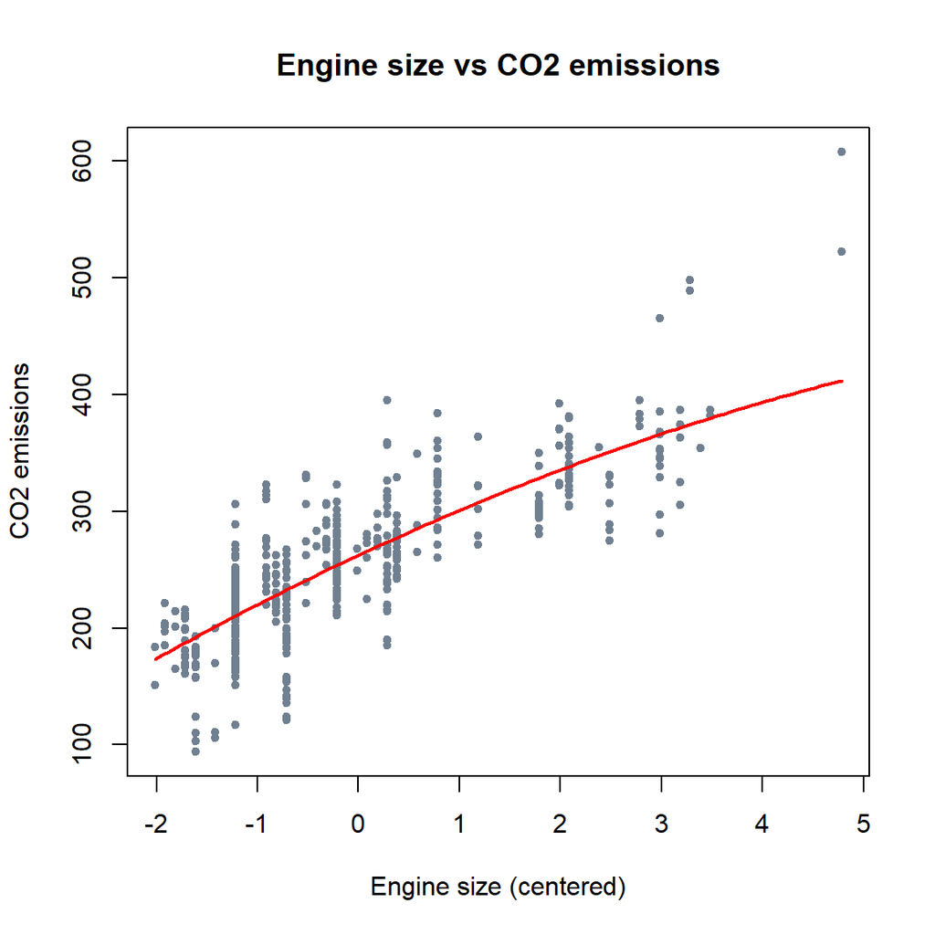

```r
# Add the polynomial regression curve
lines(x_seq, y_pred, col = "red", lwd = 2)
```

```r
#Let's try a third degree model
model_4.2 <- lm(CO2.Emissions.g.km. ~ Engine.Size.L.centered + Engine.Size.L.centered.sqr+Engine.Size.L.centered.cub, data = Case4_data_train)
summary(model_4.2)
```

```
##
## Call:
## lm(formula = CO2.Emissions.g.km. ~ Engine.Size.L.centered + Engine.Size.L.centered.sqr +
##     Engine.Size.L.centered.cub, data = Case4_data_train)
##
## Residuals:
##      Min       1Q   Median       3Q      Max
## -116.756  -20.423    0.344   20.680  118.602
##
## Coefficients:
##                            Estimate Std. Error t value Pr(>|t|)
## (Intercept)                267.0227     2.0367 131.107  < 2e-16 ***
## Engine.Size.L.centered      34.7031     1.6395  21.167  < 2e-16 ***
## Engine.Size.L.centered.sqr  -7.2176     1.1253  -6.414  2.7e-10 ***
## Engine.Size.L.centered.cub   2.1797     0.3696   5.897  5.9e-09 ***
## ---
## Signif. codes:  0 '***' 0.001 '**' 0.01 '*' 0.05 '.' 0.1 ' ' 1
##
## Residual standard error: 35.3 on 659 degrees of freedom
## Multiple R-squared:  0.6937, Adjusted R-squared:  0.6923
## F-statistic: 497.6 on 3 and 659 DF,  p-value: < 2.2e-16
```

```r
# Scatter plot with regression line centered
plot(Case4_data_train$Engine.Size.L.centered, Case4_data_train$CO2.Emissions.g.km.,
     main = "Engine size vs CO2 emissions",
     xlab = "Engine size (centered)", ylab = "CO2 emissions",
     pch = 20,
     col = "slategray",
     xlim = range(Case4_data_train$Engine.Size.L.centered),
     ylim = range(Case4_data_train$CO2.Emissions.g.km.))

# Define x-values for prediction (100 points)
x_seq <- seq(min(Case4_data_train$Engine.Size.L.centered),
             max(Case4_data_train$Engine.Size.L.centered), length.out = 100)

# Predict y-values using the model
y_pred <- predict(model_4.2,
                  newdata = data.frame(Engine.Size.L.centered = x_seq,
                                       Engine.Size.L.centered.sqr = x_seq^2,
                                       Engine.Size.L.centered.cub = x_seq^3))

# Print lengths to verify they match
print(length(x_seq))   # Should be 100
```

```
## [1] 100
```

```r
print(length(y_pred))  # Should be 100
```

```
## [1] 100
```

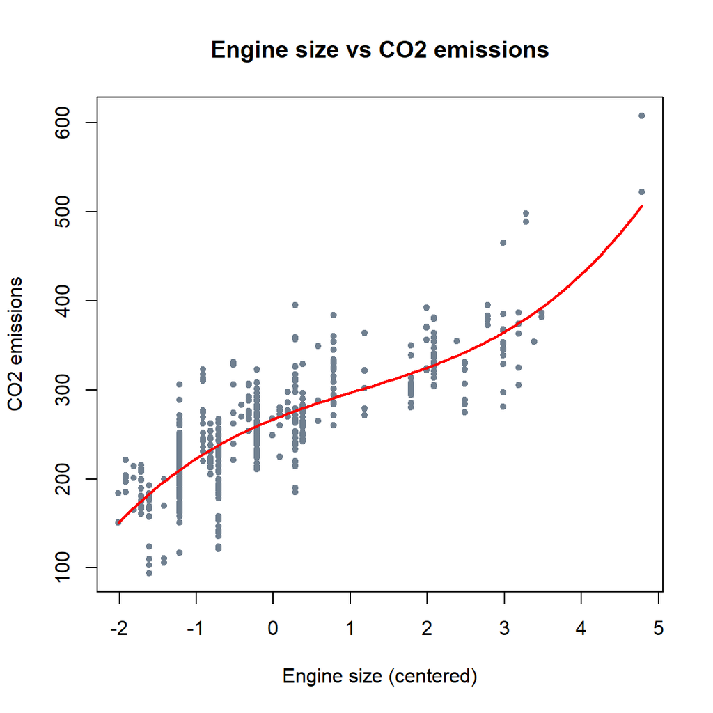

```r
# Add the polynomial regression curve
lines(x_seq, y_pred, col = "red", lwd = 2)
```

```r
#An orthogonal polynomial transforms the original variables so that each term is uncorrelated (orthogonal) with the others.it will give you a different result.
model_4.3 <- lm(CO2.Emissions.g.km. ~ poly(Engine.Size.L.centered,2), data = Case4_data_train)
summary(model_4.3)
```

```
##
## Call:
## lm(formula = CO2.Emissions.g.km. ~ poly(Engine.Size.L.centered,
##     2), data = Case4_data_train)
##
## Residuals:
##     Min      1Q  Median      3Q     Max
## -111.53  -22.09    0.49   21.40  196.06
##
## Coefficients:
##                                  Estimate Std. Error t value Pr(>|t|)
## (Intercept)                       258.724      1.406 184.070  < 2e-16 ***
## poly(Engine.Size.L.centered, 2)1 1344.165     36.192  37.140  < 2e-16 ***
## poly(Engine.Size.L.centered, 2)2  -99.689     36.192  -2.754  0.00604 **
## ---
## Signif. codes:  0 '***' 0.001 '**' 0.01 '*' 0.05 '.' 0.1 ' ' 1
##
## Residual standard error: 36.19 on 660 degrees of freedom
## Multiple R-squared:  0.6776, Adjusted R-squared:  0.6766
## F-statistic: 693.5 on 2 and 660 DF,  p-value: < 2.2e-16
```

```r
#This will match linear reqression
model_4.4 <- lm(CO2.Emissions.g.km. ~ poly(Engine.Size.L.centered,2, raw = TRUE), data = Case4_data_train)
summary(model_4.4)
```

```
##
## Call:
## lm(formula = CO2.Emissions.g.km. ~ poly(Engine.Size.L.centered,
##     2, raw = TRUE), data = Case4_data_train)
##
## Residuals:
##     Min      1Q  Median      3Q     Max
## -111.53  -22.09    0.49   21.40  196.06
##
## Coefficients:
##                                              Estimate Std. Error t value
## (Intercept)                                  262.3379     1.9228 136.438
## poly(Engine.Size.L.centered, 2, raw = TRUE)1  40.3694     1.3620  29.640
## poly(Engine.Size.L.centered, 2, raw = TRUE)2  -1.9032     0.6909  -2.754
##                                              Pr(>|t|)
## (Intercept)                                   < 2e-16 ***
## poly(Engine.Size.L.centered, 2, raw = TRUE)1  < 2e-16 ***
## poly(Engine.Size.L.centered, 2, raw = TRUE)2  0.00604 **
## ---
## Signif. codes:  0 '***' 0.001 '**' 0.01 '*' 0.05 '.' 0.1 ' ' 1
##
## Residual standard error: 36.19 on 660 degrees of freedom
## Multiple R-squared:  0.6776, Adjusted R-squared:  0.6766
## F-statistic: 693.5 on 2 and 660 DF,  p-value: < 2.2e-16
```

```r
#Let's test some interactions as well
model_4.5 <- lm(CO2.Emissions.g.km. ~ Engine.Size.L.centered +
                                         Engine.Size.L.centered.sqr +
                                         Engine.Size.L.centered * Fuel.Consumption.Comb..L.100.km..,
                data = Case4_data_train)
summary(model_4.5)
```

```
##
## Call:
## lm(formula = CO2.Emissions.g.km. ~ Engine.Size.L.centered + Engine.Size.L.centered.sqr +
##     Engine.Size.L.centered * Fuel.Consumption.Comb..L.100.km..,
##     data = Case4_data_train)
##
## Residuals:
##      Min       1Q   Median       3Q      Max
## -106.560   -2.519   -0.696    2.200   69.957
##
## Coefficients:
##                                                          Estimate Std. Error
## (Intercept)                                               27.8026     3.6759
## Engine.Size.L.centered                                    17.2457     1.9942
## Engine.Size.L.centered.sqr                                 1.8005     0.4278
## Fuel.Consumption.Comb..L.100.km..                         20.9572     0.3217
## Engine.Size.L.centered:Fuel.Consumption.Comb..L.100.km..  -1.2851     0.1862
##                                                          t value Pr(>|t|)
## (Intercept)                                                7.563 1.33e-13 ***
## Engine.Size.L.centered                                     8.648  < 2e-16 ***
## Engine.Size.L.centered.sqr                                 4.209 2.92e-05 ***
## Fuel.Consumption.Comb..L.100.km..                         65.137  < 2e-16 ***
## Engine.Size.L.centered:Fuel.Consumption.Comb..L.100.km..  -6.900 1.22e-11 ***
## ---
## Signif. codes:  0 '***' 0.001 '**' 0.01 '*' 0.05 '.' 0.1 ' ' 1
##
## Residual standard error: 13.15 on 658 degrees of freedom
## Multiple R-squared:  0.9575, Adjusted R-squared:  0.9573
## F-statistic:  3710 on 4 and 658 DF,  p-value: < 2.2e-16
```

```r
AIC(model_4.4, model_4.5)
```

```
##           df      AIC
## model_4.4  4 6645.297
## model_4.5  6 5305.204
```

```r
BIC(model_4.4, model_4.5)
```

```
##           df      BIC
## model_4.4  4 6663.285
## model_4.5  6 5332.185
```

Here we see that the interaction effect of Engine size and Fuel consumption inccreases a lot the $R^2$. It captures how fuel consumption modifies the effect of engine size on CO₂ emissions. The interaction term is highly significant (p < 0.000001), meaning it likely improves the model.

Since model_4.5 has a lower BIC, it is preferred over model_4.4.It means that the additional complexity (extra parameters) is justified by an improved model fit.

Model 4.5 is preferred because it has a significantly lower AIC. AIC favors a model that fits the data well while penalizing unnecessary complexity.

## Case 5

IPCA and climate change

Here we investigate the impact of climate change in Brazil’s inflation indicator, IPCA.

### Importing the data

```r
# Packages
library(dplyr)
library(ggplot2)
library(car)
library(GGally)
library(lmtest)
# import data
data5 <- read.csv("20250325_Dados-ipca.csv")

# Transform data
data5$Data <- as.Date(data5$Data, format = "%m/%d/%Y")


# Create lags and dummies
data5 <- data5 %>%
  arrange(data5) %>%
  mutate(
    # Lags IPCA
    IPCA_lag1 = lag(IPCA, 1),
    IPCA_lag2 = lag(IPCA, 2),
    IPCA_lag3 = lag(IPCA, 3),

    # Lags temp
    Temp_lag1 = lag(T_media, 1),
    Temp_lag2 = lag(T_media, 2),

    # Eventos extremos
    Eventos_lag1 = lag(Eventos_Extremos, 1),
    Eventos_lag2 = lag(Eventos_Extremos, 2),

    # Produção de soja (log)
    Soja_lag1 = lag(Prod_Soja, 1),
    Soja_lag2 = lag(Prod_Soja, 2),
    log_Soja_lag1 = log(Soja_lag1 + 1),
    log_Soja_lag2 = log(Soja_lag2 + 1),

    # Log IPCA (avoid zero)
    log_IPCA_lag1 = log(IPCA_lag1 + 0.0001),

    # Precipitação
    Precipita_lag1 = lag(Precipitaçao, 1),
    Precipita_lag2 = lag(Precipitaçao, 2),
    # Sazonalidade
    mes = factor(format(Data, "%m"))
  )
data5 <- na.omit(data5)


#Create a table
datatable(data5, options = list(
  pageLength = 6,
  autoWidth = TRUE,
  columnDefs = list(list(width = '150px', targets = "_all"))
), caption = "Dataset")
```

|  | Data | IPCA | IPCA_1 | Eventos_Extremos | Prod_Soja | Cambio | T_media | Precipitaçao | IPP | IPCA_lag1 | IPCA_lag2 | IPCA_lag3 | Temp_lag1 | Temp_lag2 | Eventos_lag1 | Eventos_lag2 | Soja_lag1 | Soja_lag2 | log_Soja_lag1 | log_Soja_lag2 | log_IPCA_lag1 | Precipita_lag1 | Precipita_lag2 | mes |
| --- | --- | --- | --- | --- | --- | --- | --- | --- | --- | --- | --- | --- | --- | --- | --- | --- | --- | --- | --- | --- | --- | --- | --- | --- |
| 24 | 2014-01-01 | 0.005498783 | 0.009199574 | 2 | 91283222 | 2.41 | 22.1 | 135.8 | 1.51 | 0.009199574 | 0.005401165 | 0.0056994 | 21.2 | 21.7 | 3 | 0 | 81699787 | 81338487 | 18.21856196496762 | 18.21412986963031 | -4.677786686323687 | 321.4 | 236.6 | 01 |
| 25 | 2014-02-01 | 0.006899752 | 0.005498783 | 1 | 88442511 | 2.34 | 21.8 | 124.6 | 0.32 | 0.005498783 | 0.009199574 | 0.005401165 | 22.1 | 21.2 | 2 | 3 | 91283222 | 81699787 | 18.32947757183427 | 18.21856196496762 | -5.185206026287329 | 135.8 | 321.4 | 02 |
| 26 | 2014-03-01 | 0.009200485 | 0.006899752 | 0 | 86769230 | 2.27 | 21.2 | 303.6 | -0.13 | 0.006899752 | 0.005498783 | 0.009199574 | 21.8 | 22.1 | 1 | 2 | 88442511 | 91283222 | 18.29786331698751 | 18.32947757183427 | -4.961880559125859 | 124.6 | 135.8 | 03 |
| 27 | 2014-04-01 | 0.006700219 | 0.009200485 | 0 | 86887561 | 2.23 | 21.4 | 218 | -0.97 | 0.009200485 | 0.006899752 | 0.005498783 | 21.2 | 21.8 | 0 | 1 | 86769230 | 88442511 | 18.27876263522032 | 18.29786331698751 | -4.677688729645085 | 303.6 | 124.6 | 04 |
| 28 | 2014-05-01 | 0.004599312 | 0.006700219 | 0 | 86451711 | 2.24 | 20.3 | 2.4 | -0.14 | 0.006700219 | 0.009200485 | 0.006899752 | 21.4 | 21.2 | 0 | 0 | 86887561 | 86769230 | 18.28012544995702 | 18.27876263522032 | -4.990800461436321 | 218 | 303.6 | 05 |
| 29 | 2014-06-01 | 0.003999949 | 0.004599312 | 1 | 86601018 | 2.21 | 19.4 | 7.6 | -0.3 | 0.004599312 | 0.006700219 | 0.009200485 | 20.3 | 21.4 | 0 | 0 | 86451711 | 86887561 | 18.27509657325203 | 18.28012544995702 | -5.360339163959881 | 2.4 | 218 | 06 |
| 30 | 2014-07-01 | 0.000101053 | 0.003999949 | 1 | 86639858 | 2.26 | 19 | 7 | -0.57 | 0.003999949 | 0.004599312 | 0.006700219 | 19.4 | 20.3 | 1 | 0 | 86601018 | 86451711 | 18.27682214020708 | 18.27509657325203 | -5.496780744373631 | 7.6 | 2.4 | 07 |
| 31 | 2014-08-01 | 0.002500808 | 0.000101053 | 0 | 86642526 | 2.24 | 21.2 | 0 | 0.44 | 0.000101053 | 0.003999949 | 0.004599312 | 19 | 19.4 | 1 | 1 | 86639858 | 86601018 | 18.27727053323186 | 18.27682214020708 | -8.51194200307104 | 7 | 7.6 | 08 |
| 32 | 2014-09-01 | 0.005699714 | 0.002500808 | 0 | 86204857 | 2.44 | 23.8 | 14.4 | 0.98 | 0.002500808 | 0.000101053 | 0.003999949 | 21.2 | 19 | 0 | 1 | 86642526 | 86639858 | 18.27730132689834 | 18.27727053323186 | -5.951933113002687 | 0 | 7 | 09 |
| 33 | 2014-10-01 | 0.004199196 | 0.005699714 | 0 | 86281097 | 2.48 | 23.4 | 160 | 0.4 | 0.005699714 | 0.002500808 | 0.000101053 | 23.8 | 21.2 | 0 | 0 | 86204857 | 86642526 | 18.27223709135449 | 18.27730132689834 | -5.149946672990386 | 14.4 | 0 | 10 |

[output cut: 112 more lines]

```r
summary(data5)
```

```
##       Data                 IPCA               IPCA_1          Eventos_Extremos
##  Min.   :2014-01-01   Min.   :-0.006800   Min.   :9.974e-05   Min.   :0.0000
##  1st Qu.:2016-07-08   1st Qu.: 0.002499   1st Qu.:2.601e-03   1st Qu.:0.0000
##  Median :2019-04-16   Median : 0.004400   Median :4.600e-03   Median :0.0000
##  Mean   :2019-05-11   Mean   : 0.005014   Mean   :5.407e-03   Mean   :0.6557
##  3rd Qu.:2022-01-24   3rd Qu.: 0.007474   3rd Qu.:7.724e-03   3rd Qu.:1.0000
##  Max.   :2025-01-01   Max.   : 0.016201   Max.   :1.620e-02   Max.   :6.0000
##
##    Prod_Soja             Cambio         T_media       Precipitaçao
##  Min.   : 86204857   Min.   :2.210   Min.   :18.40   Min.   :  0.00
##  1st Qu.: 96955890   1st Qu.:3.250   1st Qu.:20.82   1st Qu.:  9.85
##  Median :115339973   Median :3.980   Median :21.60   Median :119.50
##  Mean   :117501368   Mean   :4.173   Mean   :21.62   Mean   :125.20
##  3rd Qu.:132664280   3rd Qu.:5.190   3rd Qu.:22.40   3rd Qu.:212.95
##  Max.   :166543984   Max.   :6.180   Max.   :25.50   Max.   :536.20
##
##       IPP            IPCA_lag1           IPCA_lag2           IPCA_lag3
##  Min.   :-2.8800   Min.   :9.974e-05   Min.   :-0.003800   Min.   :-0.003800
##  1st Qu.:-0.1025   1st Qu.:2.601e-03   1st Qu.: 0.002499   1st Qu.: 0.002425
##  Median : 0.5950   Median :4.600e-03   Median : 0.004500   Median : 0.004400
##  Mean   : 0.7004   Mean   :5.407e-03   Mean   : 0.005090   Mean   : 0.004902
##  3rd Qu.: 1.2900   3rd Qu.:7.724e-03   3rd Qu.: 0.007724   3rd Qu.: 0.007474
##  Max.   : 5.1600   Max.   :1.620e-02   Max.   : 0.016201   Max.   : 0.016201
##
##    Temp_lag1       Temp_lag2      Eventos_lag1     Eventos_lag2
##  Min.   :17.60   Min.   :17.60   Min.   :0.0000   Min.   :0.0000
##  1st Qu.:20.82   1st Qu.:20.90   1st Qu.:0.0000   1st Qu.:0.0000
##  Median :21.65   Median :21.70   Median :0.0000   Median :0.0000
##  Mean   :21.67   Mean   :21.70   Mean   :0.6721   Mean   :0.6639
##  3rd Qu.:22.60   3rd Qu.:22.68   3rd Qu.:1.0000   3rd Qu.:1.0000
##  Max.   :25.50   Max.   :25.50   Max.   :6.0000   Max.   :6.0000
##
##    Soja_lag1           Soja_lag2         log_Soja_lag1   log_Soja_lag2
##  Min.   : 81699787   Min.   : 81338487   Min.   :18.22   Min.   :18.21
##  1st Qu.: 96922425   1st Qu.: 96893404   1st Qu.:18.39   1st Qu.:18.39
##  Median :115029137   Median :114989546   Median :18.56   Median :18.56
##  Mean   :116805620   Mean   :116294794   Mean   :18.56   Mean   :18.56
##  3rd Qu.:131903175   3rd Qu.:131822048   3rd Qu.:18.70   3rd Qu.:18.70
##  Max.   :151963045   Max.   :151963045   Max.   :18.84   Max.   :18.84
##
##  log_IPCA_lag1    Precipita_lag1   Precipita_lag2        mes
##  Min.   :-8.519   Min.   :  0.00   Min.   :  0.00   01     :12
##  1st Qu.:-5.914   1st Qu.:  9.85   1st Qu.: 10.05   02     :11
##  Median :-5.360   Median :116.40   Median :111.10   03     :11
##  Mean   :-5.433   Mean   :124.01   Mean   :122.30   04     :11
##  3rd Qu.:-4.851   3rd Qu.:212.95   3rd Qu.:204.00   11     :11
##  Max.   :-4.117   Max.   :536.20   Max.   :536.20   05     :10
##                                                     (Other):56
```

### Using stepwise selection

```r
library(MASS)

# full model
full_model <- lm(IPCA ~
                        IPCA_lag1 + IPCA_lag2 + IPCA_lag3 +
                        log_IPCA_lag1 +
                        T_media+Temp_lag1 + Temp_lag2 +
                        Eventos_Extremos + Eventos_lag1 + Eventos_lag2 +
                        Prod_Soja + log_Soja_lag1 + log_Soja_lag2 + Soja_lag1 + Soja_lag2 +
                        Precipitaçao + Precipita_lag1 + Precipita_lag2 +
                        Cambio + IPP +
                        mes,
                      data = data5)

summary(full_model)
```

```
##
## Call:
## lm(formula = IPCA ~ IPCA_lag1 + IPCA_lag2 + IPCA_lag3 + log_IPCA_lag1 +
##     T_media + Temp_lag1 + Temp_lag2 + Eventos_Extremos + Eventos_lag1 +
##     Eventos_lag2 + Prod_Soja + log_Soja_lag1 + log_Soja_lag2 +
##     Soja_lag1 + Soja_lag2 + Precipitaçao + Precipita_lag1 +
##     Precipita_lag2 + Cambio + IPP + mes, data = data5)
##
## Residuals:
##        Min         1Q     Median         3Q        Max
## -0.0099861 -0.0015991  0.0000352  0.0015281  0.0080713
##
## Coefficients:
##                    Estimate Std. Error t value Pr(>|t|)
## (Intercept)       7.926e-01  4.157e-01   1.907  0.05972 .
## IPCA_lag1         5.461e-01  2.097e-01   2.604  0.01079 *
## IPCA_lag2         7.943e-03  1.166e-01   0.068  0.94582
## IPCA_lag3         7.658e-02  1.091e-01   0.702  0.48440
## log_IPCA_lag1    -3.769e-04  8.695e-04  -0.433  0.66575
## T_media           8.767e-05  5.919e-04   0.148  0.88258
## Temp_lag1        -1.003e-03  5.351e-04  -1.875  0.06407 .
## Temp_lag2         5.057e-05  5.243e-04   0.096  0.92338
## Eventos_Extremos -5.495e-04  3.624e-04  -1.516  0.13292
## Eventos_lag1      1.273e-04  3.530e-04   0.361  0.71923
## Eventos_lag2     -5.017e-04  3.659e-04  -1.371  0.17372
## Prod_Soja        -1.103e-10  9.145e-11  -1.206  0.23086
## log_Soja_lag1    -4.844e-02  7.048e-02  -0.687  0.49367
## log_Soja_lag2     4.711e-03  6.941e-02   0.068  0.94605
## Soja_lag1         4.531e-10  5.772e-10   0.785  0.43450
## Soja_lag2        -1.048e-12  5.661e-10  -0.002  0.99853
## Precipitaçao     -4.738e-06  5.225e-06  -0.907  0.36699
## Precipita_lag1   -9.691e-06  4.650e-06  -2.084  0.03998 *
## Precipita_lag2   -6.865e-06  4.794e-06  -1.432  0.15561
## Cambio            7.896e-04  6.785e-04   1.164  0.24760
## IPP               6.479e-04  2.727e-04   2.375  0.01965 *
## mes02             1.500e-03  1.885e-03   0.796  0.42836
## mes03            -1.397e-04  1.573e-03  -0.089  0.92944
## mes04            -2.340e-03  1.608e-03  -1.455  0.14908
## mes05            -2.681e-03  2.377e-03  -1.128  0.26234
## mes06            -5.966e-03  3.076e-03  -1.940  0.05556 .
## mes07            -9.650e-03  3.503e-03  -2.755  0.00710 **
## mes08            -1.019e-02  3.329e-03  -3.060  0.00292 **
## mes09            -6.159e-03  3.243e-03  -1.899  0.06075 .
## mes10            -2.403e-03  2.459e-03  -0.977  0.33105
## mes11            -1.230e-03  1.958e-03  -0.628  0.53164
## mes12             1.180e-03  1.793e-03   0.658  0.51228
## ---
## Signif. codes:  0 '***' 0.001 '**' 0.01 '*' 0.05 '.' 0.1 ' ' 1
##
## Residual standard error: 0.003057 on 90 degrees of freedom
## Multiple R-squared:  0.5295, Adjusted R-squared:  0.3675
## F-statistic: 3.267 on 31 and 90 DF,  p-value: 6.697e-06
```

```r
# Stepwise based em AIC
step_model <- stepAIC(full_model, direction = "both", trace = FALSE)
summary(step_model)
```

```
##
## Call:
## lm(formula = IPCA ~ IPCA_lag1 + Temp_lag1 + Eventos_Extremos +
##     Eventos_lag2 + Prod_Soja + log_Soja_lag1 + Soja_lag1 + Precipitaçao +
##     Precipita_lag1 + Precipita_lag2 + Cambio + IPP + mes, data = data5)
##
## Residuals:
##        Min         1Q     Median         3Q        Max
## -0.0099043 -0.0016741  0.0000137  0.0016310  0.0076523
##
## Coefficients:
##                    Estimate Std. Error t value Pr(>|t|)
## (Intercept)       8.819e-01  3.717e-01   2.373 0.019603 *
## IPCA_lag1         4.897e-01  9.277e-02   5.279 7.81e-07 ***
## Temp_lag1        -9.854e-04  4.618e-04  -2.134 0.035347 *
## Eventos_Extremos -5.017e-04  3.455e-04  -1.452 0.149585
## Eventos_lag2     -4.834e-04  3.378e-04  -1.431 0.155566
## Prod_Soja        -1.260e-10  8.520e-11  -1.479 0.142287
## log_Soja_lag1    -4.847e-02  2.106e-02  -2.301 0.023489 *
## Soja_lag1         4.969e-10  1.984e-10   2.504 0.013930 *
## Precipitaçao     -5.322e-06  3.824e-06  -1.392 0.167137
## Precipita_lag1   -9.378e-06  4.365e-06  -2.149 0.034137 *
## Precipita_lag2   -7.266e-06  3.806e-06  -1.909 0.059192 .
## Cambio            1.014e-03  6.095e-04   1.663 0.099478 .
## IPP               6.145e-04  2.603e-04   2.361 0.020213 *
## mes02             1.292e-03  1.483e-03   0.871 0.385683
## mes03             4.221e-06  1.491e-03   0.003 0.997748
## mes04            -2.223e-03  1.431e-03  -1.554 0.123493
## mes05            -2.735e-03  1.703e-03  -1.606 0.111531
## mes06            -6.158e-03  2.213e-03  -2.783 0.006471 **
## mes07            -1.009e-02  2.774e-03  -3.637 0.000442 ***
## mes08            -1.047e-02  2.864e-03  -3.654 0.000416 ***
## mes09            -6.510e-03  2.373e-03  -2.744 0.007228 **
## mes10            -2.547e-03  1.995e-03  -1.277 0.204776
## mes11            -1.591e-03  1.795e-03  -0.886 0.377716
## mes12             1.016e-03  1.615e-03   0.629 0.530851
## ---
## Signif. codes:  0 '***' 0.001 '**' 0.01 '*' 0.05 '.' 0.1 ' ' 1
##
## Residual standard error: 0.002952 on 98 degrees of freedom
## Multiple R-squared:  0.5223, Adjusted R-squared:  0.4101
## F-statistic: 4.658 on 23 and 98 DF,  p-value: 3.794e-08
```

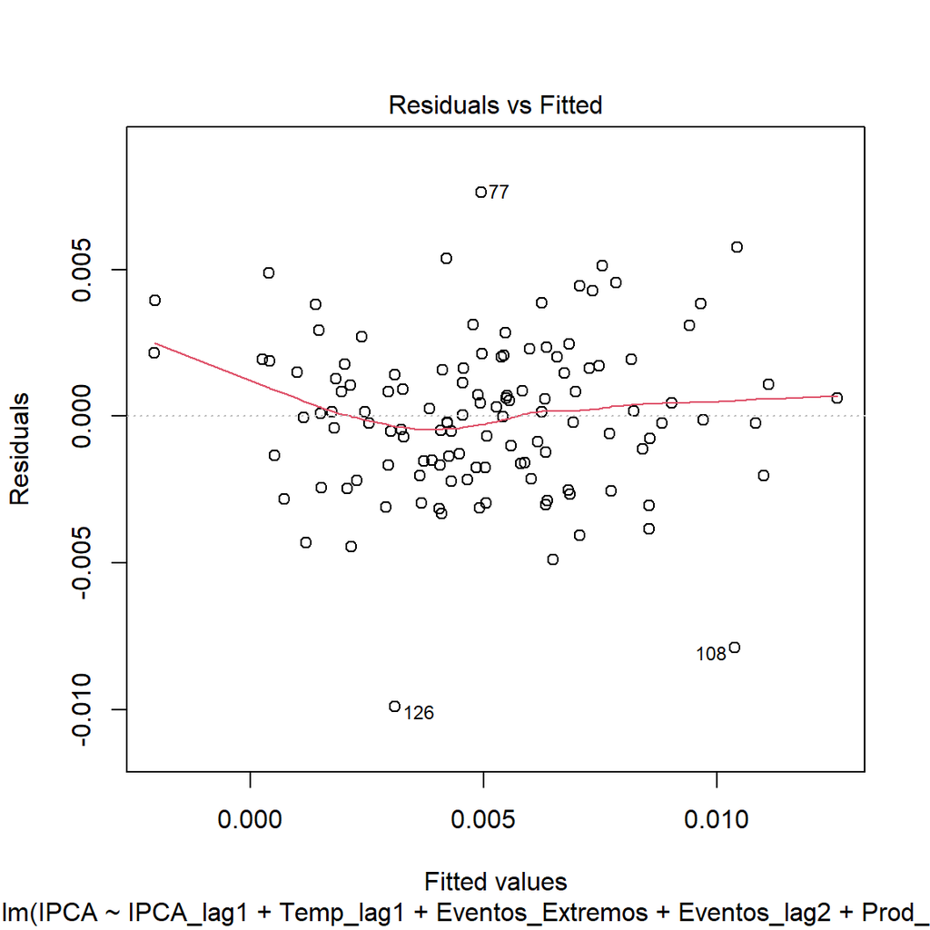

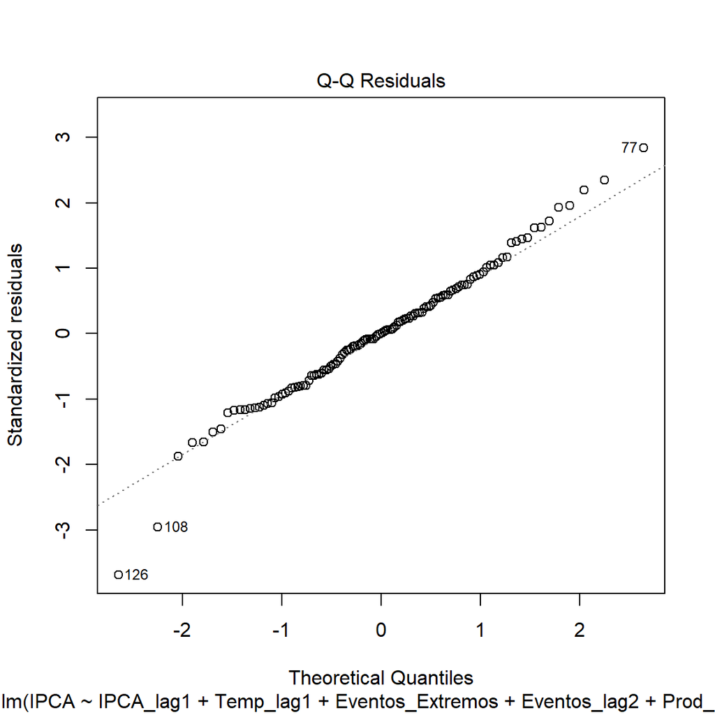

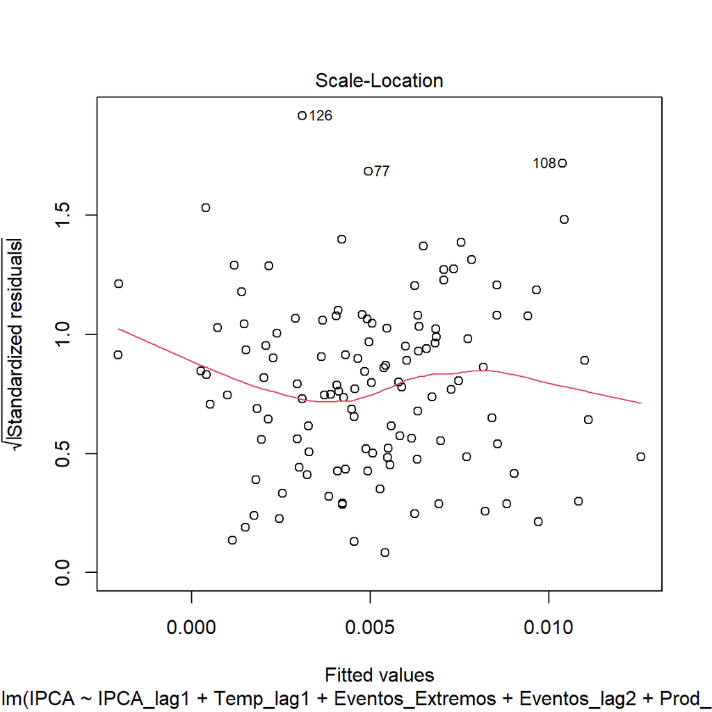

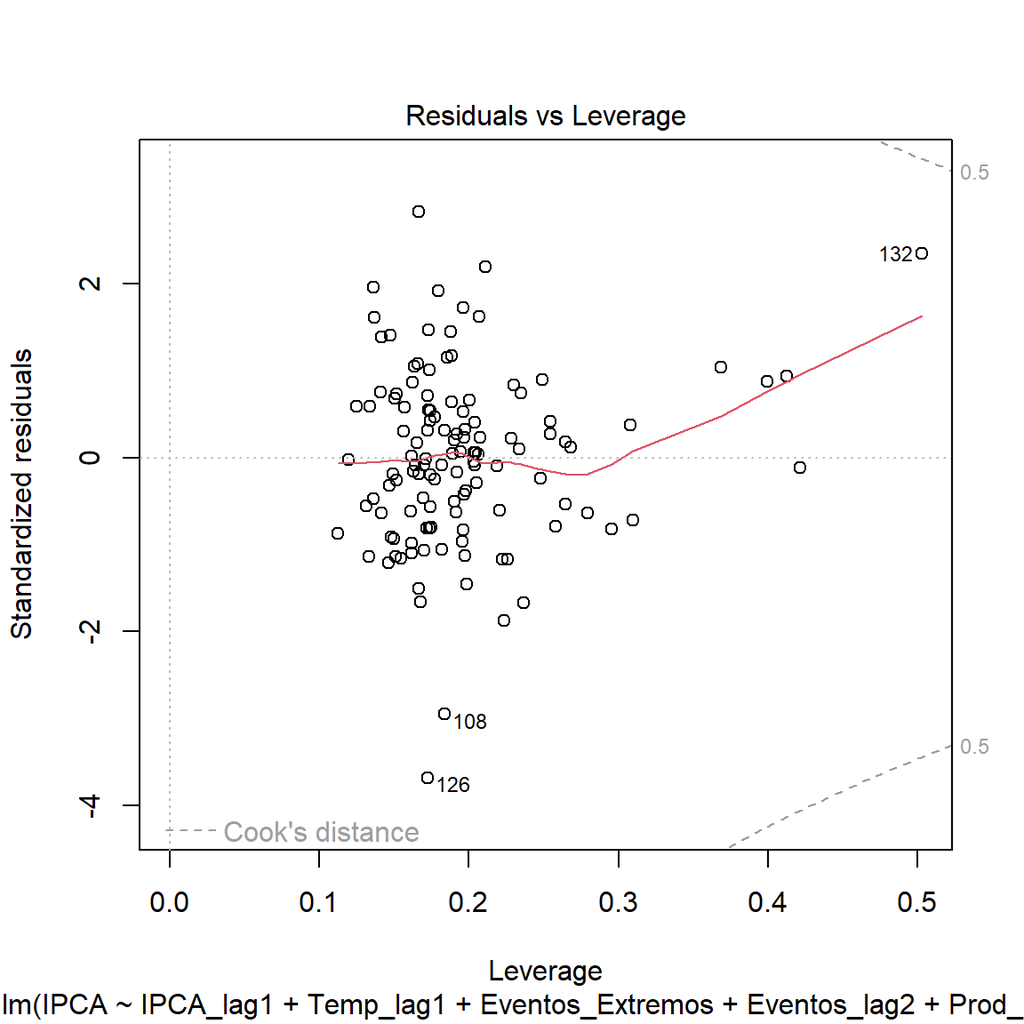

```r
plot(step_model)
```

```r
# Verify variables
vars_selecionadas <- names(coef(step_model))[-1]
vars_selecionadas
```

```
##  [1] "IPCA_lag1"        "Temp_lag1"        "Eventos_Extremos" "Eventos_lag2"
##  [5] "Prod_Soja"        "log_Soja_lag1"    "Soja_lag1"        "Precipitaçao"
##  [9] "Precipita_lag1"   "Precipita_lag2"   "Cambio"           "IPP"
## [13] "mes02"            "mes03"            "mes04"            "mes05"
## [17] "mes06"            "mes07"            "mes08"            "mes09"
## [21] "mes10"            "mes11"            "mes12"
```

### Creating new model

```r
library(MASS)
library(dplyr)
library(purrr)
```

```r
# Shared variables
grupo_ipca     <- c("IPCA_lag1", "IPCA_lag2", "IPCA_lag3", "log_IPCA_lag1")
grupo_temp     <- c("T_media", "Temp_lag1", "Temp_lag2")
grupo_soja     <- c("Prod_Soja", "Soja_lag1", "log_Soja_lag1", "log_Soja_lag2")
grupo_eventos  <- c("Eventos_Extremos", "Eventos_lag2")
grupo_precip   <- c("Precipitaçao", "Precipita_lag1", "Precipita_lag2")

# Fixed variables
fixas <- c("IPP", "Cambio")

# List to store models
resultados <- list()
contador <- 1

# Generate all combinations
for (ipca in grupo_ipca) {
  for (temp in grupo_temp) {
    for (soja in grupo_soja) {
      for (evento in grupo_eventos) {
        for (i in 1:2) {  # permitir 1 ou 2 of precipitation variables , not highly correlated.
          combinacoes_precip <- combn(grupo_precip, i, simplify = FALSE)

          for (precip in combinacoes_precip) {
            vars_modelo <- c(fixas, ipca, temp, soja, evento, precip)
            formula_txt <- paste("IPCA ~", paste(vars_modelo, collapse = " + "))
            formula_obj <- as.formula(formula_txt)
            modelo <- lm(formula_obj, data = data5)
            aic_val <- AIC(modelo)

            resultados[[contador]] <- list(formula = formula_txt,
                                           modelo = modelo,
                                           AIC = aic_val)
            contador <- contador + 1
          }
        }
      }
    }
  }
}

# Filter signs coherence
modelos_filtrados <- resultados %>%
  keep(~{
    coef <- coef(.x$modelo)
    coerente <- TRUE

    if ("Temp_lag1" %in% names(coef)) {
      coerente <- coerente && coef["Temp_lag1"] > 0
    }
    if ("T_media" %in% names(coef)) {
      coerente <- coerente && coef["T_media"] > 0
    }
    if ("Eventos_Extremos" %in% names(coef)) {
      coerente <- coerente && coef["Eventos_Extremos"] > 0
    }
    TRUE
  })

# Verify at least one coherent model
if (length(modelos_filtrados) == 0) {
  stop("Not found.")
}

# Choose coherent model (lower AIC)
df_coerentes <- map_dfr(modelos_filtrados, ~{
  tibble(
    formula = .x$formula,
    AIC = .x$AIC
  )
})

melhor_formula <- df_coerentes %>%
  arrange(AIC) %>%
  slice(1)

melhor_modelo <- modelos_filtrados[[which(df_coerentes$formula == melhor_formula$formula)]]

# Results
cat(" Best model:\n", melhor_modelo$formula, "\n")
```

```
##  Best model:
##  IPCA ~ IPP + Cambio + IPCA_lag1 + Temp_lag2 + Prod_Soja + Eventos_Extremos + Precipita_lag2
```

```r
summary(melhor_modelo$modelo)
```

```
##
## Call:
## lm(formula = formula_obj, data = data5)
##
## Residuals:
##        Min         1Q     Median         3Q        Max
## -0.0117038 -0.0015049  0.0000637  0.0015452  0.0077142
##
## Coefficients:
##                    Estimate Std. Error t value Pr(>|t|)
## (Intercept)      -7.829e-03  4.716e-03  -1.660   0.0996 .
## IPP               6.395e-04  2.655e-04   2.409   0.0176 *
## Cambio            3.315e-04  5.740e-04   0.578   0.5647
## IPCA_lag1         5.215e-01  9.363e-02   5.570 1.72e-07 ***
## Temp_lag2         5.440e-04  1.955e-04   2.783   0.0063 **
## Prod_Soja        -2.942e-11  3.044e-11  -0.967   0.3358
## Eventos_Extremos -3.772e-04  3.425e-04  -1.101   0.2731
## Precipita_lag2    7.398e-07  2.554e-06   0.290   0.7726
## ---
## Signif. codes:  0 '***' 0.001 '**' 0.01 '*' 0.05 '.' 0.1 ' ' 1
##
## Residual standard error: 0.003162 on 114 degrees of freedom
## Multiple R-squared:  0.3625, Adjusted R-squared:  0.3234
## F-statistic: 9.261 on 7 and 114 DF,  p-value: 4.867e-09
```

```r
# Create model considering lags
model5b <- lm(IPCA ~ IPP  + IPCA_lag1 + Temp_lag2 + Prod_Soja + Eventos_lag1 + Precipita_lag2 , data = data5)

summary(model5b)
```

```
##
## Call:
## lm(formula = IPCA ~ IPP + IPCA_lag1 + Temp_lag2 + Prod_Soja +
##     Eventos_lag1 + Precipita_lag2, data = data5)
##
## Residuals:
##        Min         1Q     Median         3Q        Max
## -0.0115595 -0.0013841  0.0000525  0.0015831  0.0080834
##
## Coefficients:
##                  Estimate Std. Error t value Pr(>|t|)
## (Intercept)    -6.476e-03  4.424e-03  -1.464   0.1460
## IPP             7.321e-04  2.387e-04   3.067   0.0027 **
## IPCA_lag1       5.195e-01  8.798e-02   5.904 3.66e-08 ***
## Temp_lag2       5.018e-04  1.924e-04   2.608   0.0103 *
## Prod_Soja      -2.437e-11  1.500e-11  -1.625   0.1069
## Eventos_lag1    3.792e-04  3.130e-04   1.211   0.2283
## Precipita_lag2 -9.219e-07  2.505e-06  -0.368   0.7135
## ---
## Signif. codes:  0 '***' 0.001 '**' 0.01 '*' 0.05 '.' 0.1 ' ' 1
##
## Residual standard error: 0.003151 on 115 degrees of freedom
## Multiple R-squared:  0.3616, Adjusted R-squared:  0.3283
## F-statistic: 10.86 on 6 and 115 DF,  p-value: 1.502e-09
```

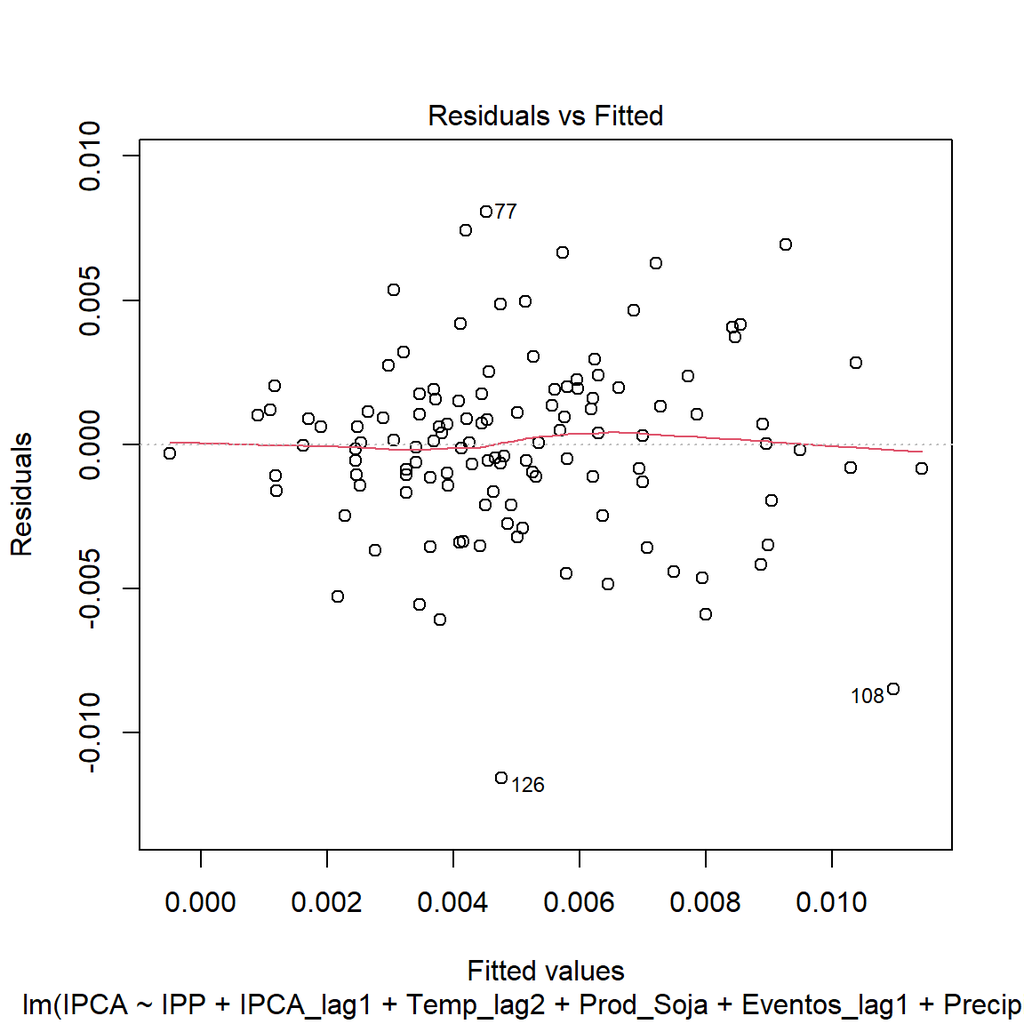

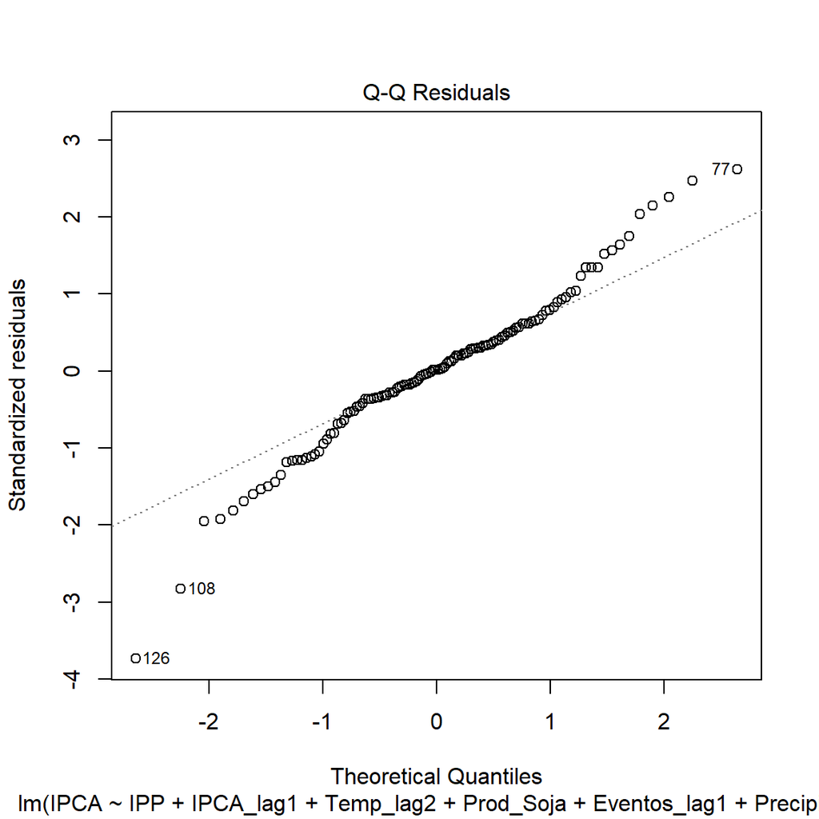

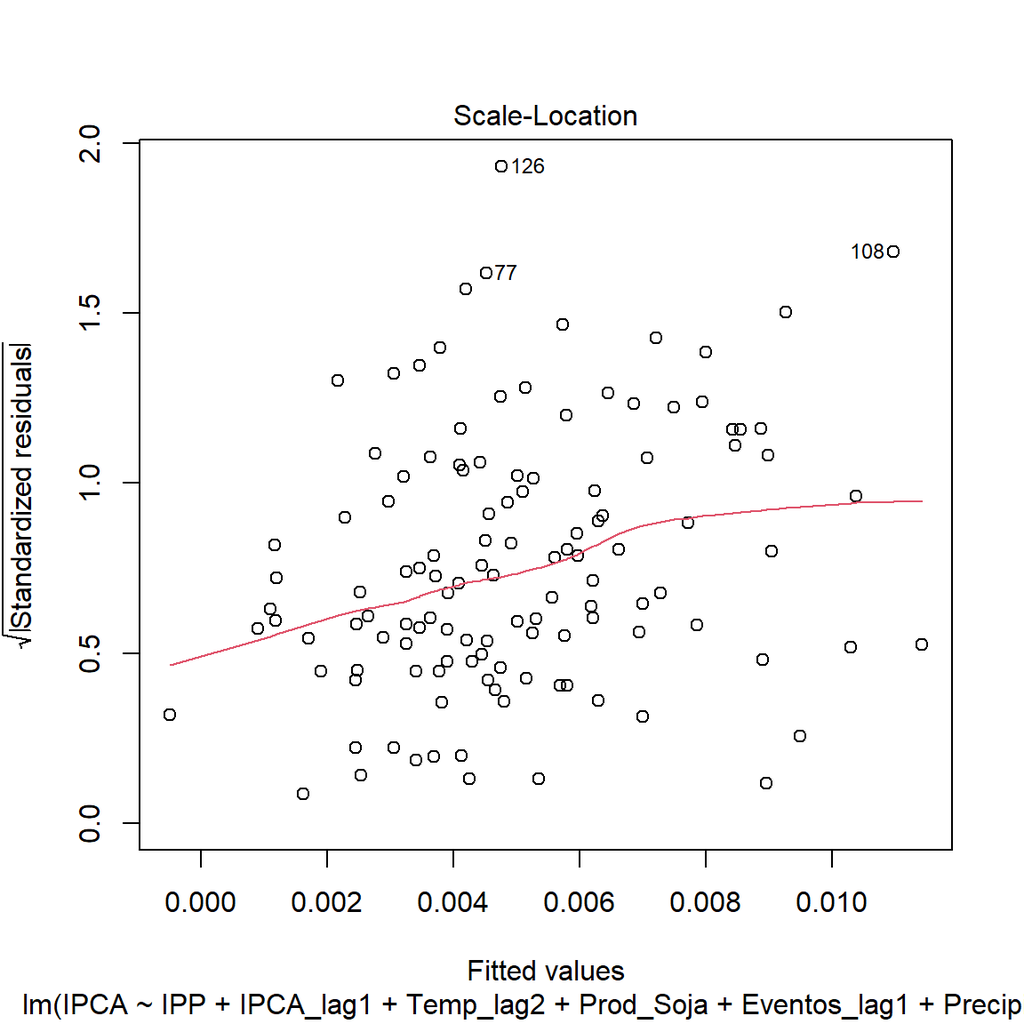

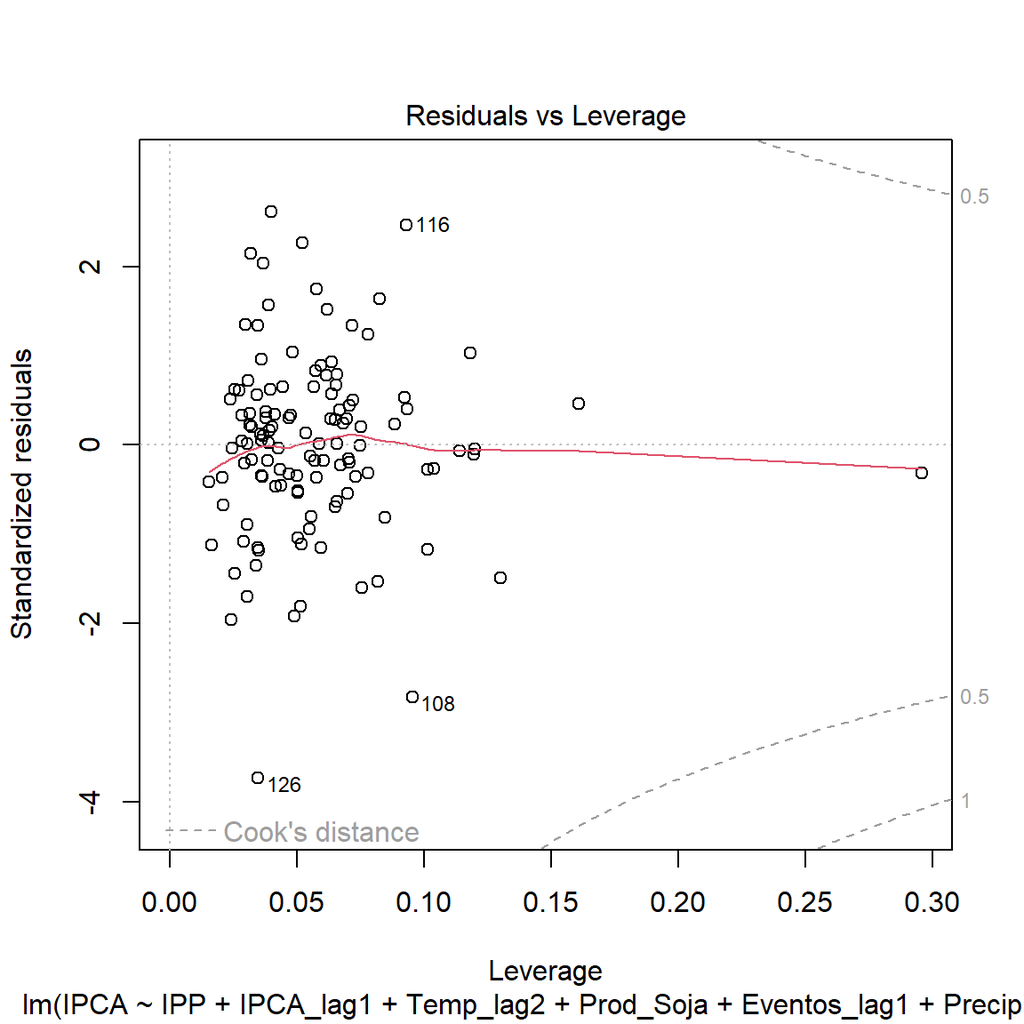

```r
plot(model5b)
```

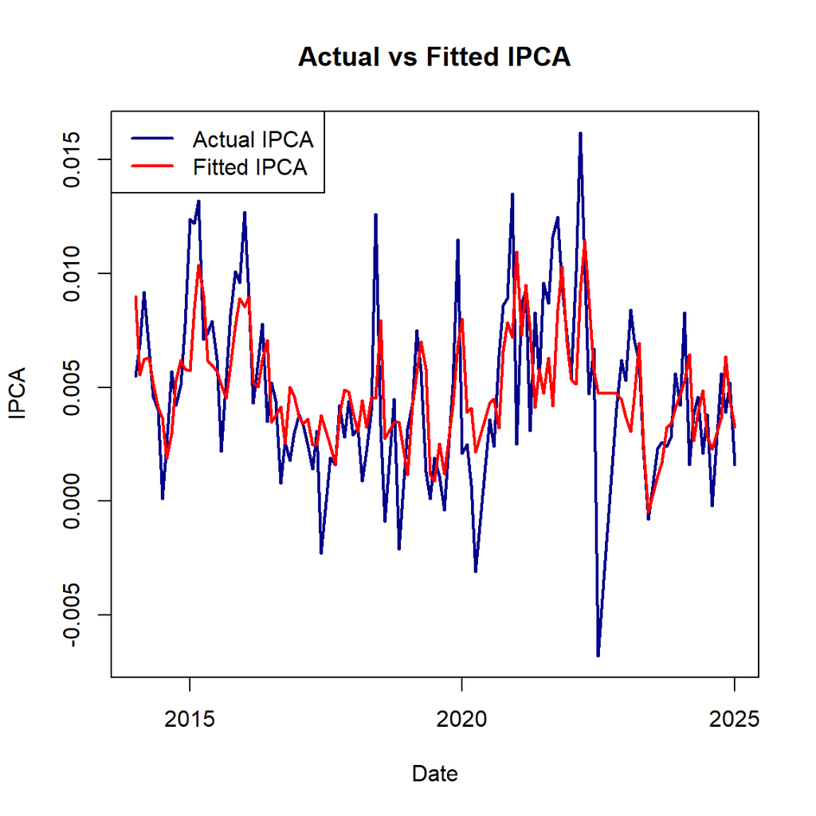

```r
# Plot actual IPCA values
plot(data5$Data, data5$IPCA, type = "l", col = "darkblue", lwd = 2,
     ylab = "IPCA", xlab = "Date", main = "Actual vs Fitted IPCA")

# Add fitted values from model
lines(data5$Data, fitted(model5b), col = "red", lwd = 2)

# Add a legend
legend("topleft", legend = c("Actual IPCA", "Fitted IPCA"),
       col = c("darkblue", "red"), lty = 1, lwd = 2)
```

```r
delta_temp <- 1  # aumento de 1 grau
efeito_temp <- coef(model5b)["Temp_lag2"] * delta_temp
print(efeito_temp)
```

```
##    Temp_lag2
## 0.0005018021
```

```r
confint(model5b, "Temp_lag2", level = 0.95)
```

```
##                  2.5 %     97.5 %
## Temp_lag2 0.0001206742 0.00088293
```

Temperature lagged 2 months is significant: this supports the idea that heat can cause inflation, likely by affecting crop yields, supply chains, or energy costs.

Extreme events have a positive (but not yet significant) effect: more data or better granularity might make it stronger.

For 1 C increase, inflation rises 0.05 pp (0.01 - 0.09, at 95% conf.level).

## Case 6

Classification of countries based on their GHG emissions level, using Decision Trees

```r
#Packages
library(WDI)
library(rpart)
library(rpart.plot)
library(ggplot2)
library(DT)

#Load the data

#data_6 <- WDI(country = "all",
#              indicator = c("EN.GHG.ALL.PC.CE.AR5",
#                            "NY.GDP.PCAP.CD",
#                            "SP.POP.TOTL",
#                            "EG.FEC.RNEW.ZS",
#                            "AG.LND.FRST.ZS",
#                            "EG.USE.PCAP.KG.OE",
#                            "SP.URB.TOTL.IN.ZS"),
#              start = 2020, end = 2020, extra = TRUE)

#write.csv(data_6, "ghg_classification_data_2020.csv", row.names = FALSE)


data_6 <- read.csv("ghg_classification_data_2020.csv")

#Create a table
datatable(data_6 , options = list(
  pageLength = 6,
  autoWidth = TRUE,
  columnDefs = list(list(width = '150px', targets = "_all"))
), caption = "Dataset")
```

|  | country | iso2c | iso3c | year | status | lastupdated | EN.GHG.ALL.PC.CE.AR5 | NY.GDP.PCAP.CD | SP.POP.TOTL | EG.FEC.RNEW.ZS | AG.LND.FRST.ZS | EG.USE.PCAP.KG.OE | SP.URB.TOTL.IN.ZS | region | capital | longitude | latitude | income | lending |
| --- | --- | --- | --- | --- | --- | --- | --- | --- | --- | --- | --- | --- | --- | --- | --- | --- | --- | --- | --- |
| 1 | Afghanistan | AF | AFG | 2020 |  | 2025-03-24 | 0.682032156509644 | 510.787063366811 |  | 18.2 | 1.85278199408184 |  | 26.026 | South Asia | Kabul | 69.1761 | 34.5228 | Low income | IDA |
| 2 | Afghanistan | AF | AFG | 2020 |  | 2024-06-25 |  |  |  |  |  |  |  | South Asia | Kabul | 69.1761 | 34.5228 | Low income | IDA |
| 3 | Africa Eastern and Southern | ZH | AFE | 2020 |  | 2025-03-24 | 2.07938591869319 | 1344.08096192004 |  | 66.1234486957514 | 30.1742524356603 |  | 36.8840344817359 | Aggregates |  |  |  | Aggregates | Aggregates |
| 4 | Africa Western and Central | ZI | AFW | 2020 |  | 2025-03-24 | 1.82585874577476 | 1664.24917643553 |  | 76.1028186880091 | 19.8167839774834 |  | 47.9310209575797 | Aggregates |  |  |  | Aggregates | Aggregates |
| 5 | Albania | AL | ALB | 2020 |  | 2025-03-24 | 2.8075489569741 | 5370.77862312929 |  | 44.4 | 28.7919708029197 |  | 62.112 | Europe &amp; Central Asia | Tirane | 19.8172 | 41.3317 | Upper middle income | IBRD |
| 6 | Albania | AL | ALB | 2020 |  | 2024-06-25 |  |  |  |  |  |  |  | Europe &amp; Central Asia | Tirane | 19.8172 | 41.3317 | Upper middle income | IBRD |
| 7 | Algeria | DZ | DZA | 2020 |  | 2024-06-25 |  |  |  |  |  |  |  | Middle East &amp; North Africa | Algiers | 3.05097 | 36.7397 | Upper middle income | IBRD |
| 8 | Algeria | DZ | DZA | 2020 |  | 2025-03-24 | 5.4750352339084 | 3743.5419522929 |  | 0.1 | 0.818308959706366 |  | 73.733 | Middle East &amp; North Africa | Algiers | 3.05097 | 36.7397 | Upper middle income | IBRD |
| 9 | American Samoa | AS | ASM | 2020 |  | 2025-03-24 | 0.170816502883784 | 14489.2586563775 |  | 0.4 | 85.65 |  | 87.153 | East Asia &amp; Pacific | Pago Pago | -170.691 | -14.2846 | High income | Not classified |
| 10 | American Samoa | AS | ASM | 2020 |  | 2024-06-25 |  |  |  |  |  |  |  | East Asia &amp; Pacific | Pago Pago | -170.691 | -14.2846 | High income | Not classified |

[output cut: 528 more lines]

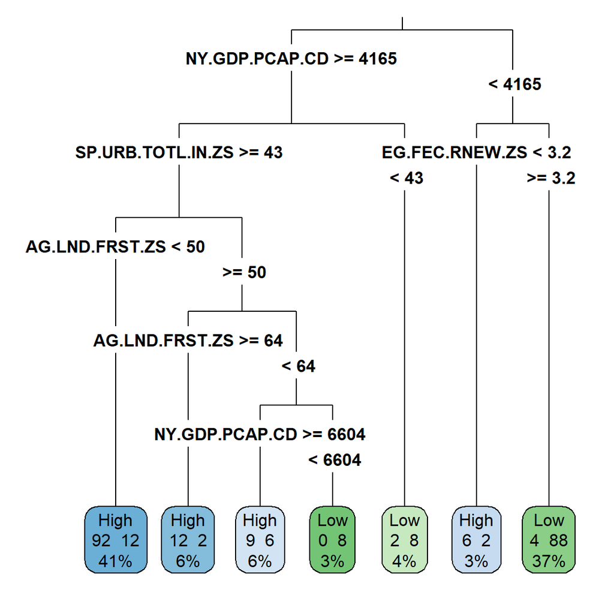

```r
# Create simple categorical variable

data_6$CO2_level <- ifelse(data_6$EN.GHG.ALL.PC.CE.AR5 > median(data_6$EN.GHG.ALL.PC.CE.AR5, na.rm = TRUE),
                           "High", "Low")
data_6$CO2_level <- factor(data_6$CO2_level)



# Decision tree model
model_6 <- rpart(CO2_level ~ NY.GDP.PCAP.CD + SP.POP.TOTL + EG.FEC.RNEW.ZS +
                               AG.LND.FRST.ZS + EG.USE.PCAP.KG.OE + SP.URB.TOTL.IN.ZS,
                 data = data_6, method = "class")



# Visualize
rpart.plot(model_6, type=3, extra=101, fallen.leaves=TRUE)
```

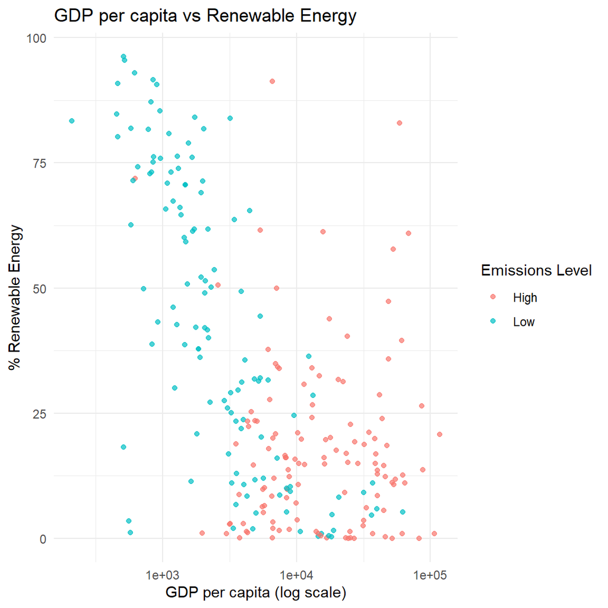

```r
plot_data <- data_6 %>%
  dplyr::filter(!is.na(NY.GDP.PCAP.CD),
                !is.na(EG.FEC.RNEW.ZS),
                !is.na(CO2_level),
                NY.GDP.PCAP.CD > 0)

ggplot(plot_data, aes(x=NY.GDP.PCAP.CD, y=EG.FEC.RNEW.ZS, color=CO2_level)) +
    geom_point(alpha=0.7) +
    scale_x_log10() +
    labs(title="GDP per capita vs Renewable Energy",
         x="GDP per capita (log scale)",
         y="% Renewable Energy",
         color="Emissions Level") +
    theme_minimal()
```

## Case 7

Let’s try to analyse the relationship between inflation (IPCA) and the unemployment rate, import prices, and inflation expectations in Brazil.

```r
library(tidyverse)
library(lubridate)
library(forecast)
# Load the dataset
data7 <- read.csv('20250418_IPCA_Philips.csv')
data7$Date <- as.Date(data7$Date, format = "%m/%d/%Y")


# Check for missing values
head(data7)
```

```
##         Date  IPCA Desemprego Exp_IPCA    IMP
## 1 2012-04-01 0.433      0.078    0.510  0.027
## 2 2012-05-01 0.403      0.077    0.477  0.076
## 3 2012-06-01 0.390      0.076    0.407 -0.003
## 4 2012-07-01 0.347      0.075    0.300 -0.008
## 5 2012-08-01 0.367      0.074    0.247 -0.017
## 6 2012-09-01 0.523      0.071    0.307 -0.018
```

```r
# Correlation matrix
cor(data7[, c('IPCA', 'Desemprego', 'Exp_IPCA', 'IMP')])
```

```
##                   IPCA  Desemprego   Exp_IPCA         IMP
## IPCA        1.00000000 -0.06534087  0.7633941  0.08099533
## Desemprego -0.06534087  1.00000000 -0.2342078  0.21246389
## Exp_IPCA    0.76339413 -0.23420780  1.0000000 -0.14857354
## IMP         0.08099533  0.21246389 -0.1485735  1.00000000
```

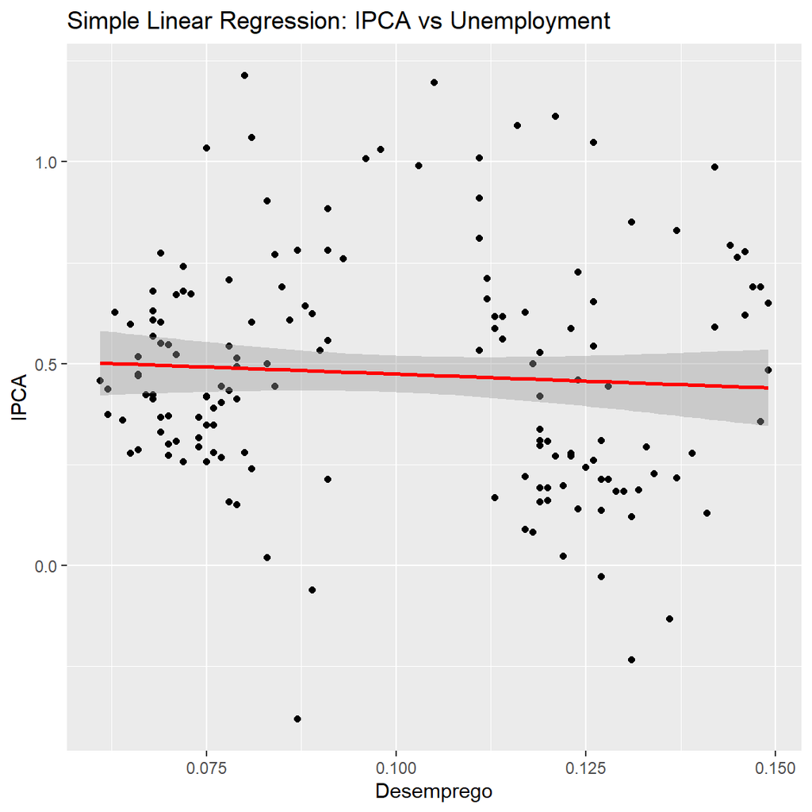

```r
# Plot the regression line
ggplot(data7, aes(x = Desemprego, y = IPCA)) +
  geom_point() +
  geom_smooth(method = "lm", col = "red") +
  ggtitle("Simple Linear Regression: IPCA vs Unemployment")
```

```r
# Lagged variables to include autocorrelation
data7$Desemprego_lag <- lag(data7$Desemprego, 1)
data7$IPCA_lag <- lag(data7$IPCA, 1)
data7$Desemprego_lag2 <- lag(data7$Desemprego, 2)
data7$IPCA_lag2 <- lag(data7$IPCA, 2)

# Fit a regression model with lagged variables
model_lagged <- lm(IPCA ~  Exp_IPCA + IMP +Desemprego_lag2, data = data7)
summary(model_lagged)
```

```
##
## Call:
## lm(formula = IPCA ~ Exp_IPCA + IMP + Desemprego_lag2, data = data7)
##
## Residuals:
##      Min       1Q   Median       3Q      Max
## -0.44067 -0.10816 -0.00244  0.12405  0.42959
##
## Coefficients:
##                 Estimate Std. Error t value Pr(>|t|)
## (Intercept)     -0.21074    0.07455  -2.827 0.005345 **
## Exp_IPCA         1.34394    0.08339  16.116  < 2e-16 ***
## IMP              1.29163    0.36498   3.539 0.000535 ***
## Desemprego_lag2  1.18999    0.56869   2.093 0.038077 *
## ---
## Signif. codes:  0 '***' 0.001 '**' 0.01 '*' 0.05 '.' 0.1 ' ' 1
##
## Residual standard error: 0.1748 on 150 degrees of freedom
##   (2 observations deleted due to missingness)
## Multiple R-squared:  0.6396, Adjusted R-squared:  0.6324
## F-statistic: 88.74 on 3 and 150 DF,  p-value: < 2.2e-16
```

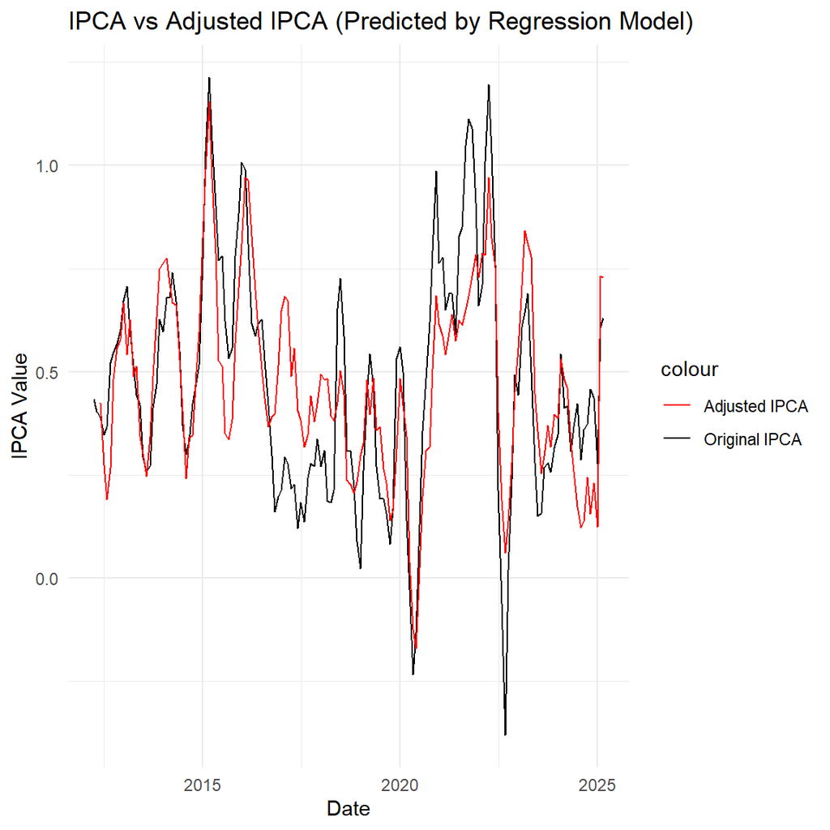

```r
# Create a new column for the fitted (adjusted) IPCA values from the regression model
data7$IPCA_adjusted <- predict(model_lagged, newdata = data7)

# Plot the original and adjusted IPCA values
ggplot(data7, aes(x = Date)) +
  geom_line(aes(y = IPCA, color = "Original IPCA")) +  # Plot original IPCA
  geom_line(aes(y = IPCA_adjusted, color = "Adjusted IPCA")) +  # Plot adjusted IPCA
  ggtitle("IPCA vs Adjusted IPCA (Predicted by Regression Model)") +
  xlab("Date") +
  ylab("IPCA Value") +
  scale_color_manual(values = c("Original IPCA" = "black", "Adjusted IPCA" = "red")) +
  theme_minimal()
```

```r
# Step 1: Load libraries
library(neuralnet)
library(readr)
library(ggplot2)

set.seed(126)
# Step 2: Load and explore data
ipca_data <- read_csv("20250418_IPCA_Philips.csv")
# Step 3: Normalize
normalize <- function(x) {
  return((x - min(x)) / (max(x) - min(x)))
}
ipca_norm <- as.data.frame(lapply(ipca_data[ , 2:5], normalize))  # exclude Date

# Step 4: Train neural network on ALL data
ipca_model <- neuralnet(IPCA ~ Desemprego + Exp_IPCA + IMP,
                        data = ipca_norm,
                        hidden = c(6, 4),
                        linear.output = FALSE)





# Step 5: Plot network
plot(ipca_model)

# Step 6: Predictions (on the same data)
model_results <- compute(ipca_model, ipca_norm[ , c("Desemprego", "Exp_IPCA", "IMP")])
predicted_ipca <- model_results$net.result

# Step 7: Evaluate
cor(predicted_ipca, ipca_norm$IPCA)  # now on all data
```

```
##           [,1]
## [1,] 0.8463909
```

```r
# Step 8: Unnormalize
unnormalize <- function(x, min_value, max_value) {
  return(x * (max_value - min_value) + min_value)
}

min_ipca <- min(ipca_data$IPCA)
max_ipca <- max(ipca_data$IPCA)



predicted_ipca_unnorm <- unnormalize(predicted_ipca, min_ipca, max_ipca)
actual_ipca_unnorm    <- ipca_data$IPCA

# Step 9: Plot Real vs Predicted
plot_data_nn <- data.frame(
  Date = as.Date(ipca_data$Date, format = "%m/%d/%Y"),  # Correct Date conversion
  IPCA_Real = ipca_data$IPCA,                            # Real IPCA
  IPCA_Predicted = predicted_ipca_unnorm                 # Predicted IPCA (full data)
)

graph_nn <- ggplot(plot_data_nn, aes(x = Date)) +
  geom_line(aes(y = IPCA_Real, color = "Real IPCA")) +
  geom_line(aes(y = IPCA_Predicted, color = "Predicted IPCA (NN)")) +
  ggtitle("IPCA: Real vs Predicted (Neural Network - Full Data)") +
  xlab("Date") +
  ylab("IPCA Value") +
  scale_color_manual(values = c("Real IPCA" = "black", "Predicted IPCA (NN)" = "blue")) +
  theme_minimal()
print(graph_nn)

# Optional: RMSE
sqrt(mean((predicted_ipca_unnorm - actual_ipca_unnorm)^2))
```

[output not shown]

```
## [1] 0.1522532
```

```r
# Total Sum of Squares
sst <- sum((actual_ipca_unnorm - mean(actual_ipca_unnorm))^2)

# Residual Sum of Squares
sse <- sum((predicted_ipca_unnorm - actual_ipca_unnorm)^2)

# R-squared
r_squared <- 1 - (sse / sst)
r_squared
```

```
## [1] 0.7159205
```

[figure not shown]

# Other concepts

## MACC

The Marginal Abatement Cost Curve (MACC) is a graphical representation used to compare the cost-effectiveness of emission reduction projects. Each bar in the curve represents a specific mitigation project or intervention, ordered from the lowest to highest cost per unit of CO₂-equivalent (tCO₂e) avoide.

The MACC allows decision-makers to:

- Prioritize projects that offer greater emissions reductions at lower cost.
- Identify no-regret” options (projects with negative or near-zero cost).
- Compare the cost-effectiveness of mitigation strategies under different scenarios.

The Marginal Abatement Cost (MAC) of a project is calculated as the net present value of the cost divided by the total emissions avoided over its lifetime:

$$\begin{align*}
\text{MAC} (USD/tCO₂e) = \frac{\text{Net Present Cost
(USD)}}{\text{Total Emissions Abated (tCO₂e)}}
\end{align*}$$

Where:

- Numerator includes capital expenditure (CAPEX), operational costs (OPEX), and any savings or revenues, all discounted over time.
- Denominator is the total amount of CO₂-equivalent avoided by the project, typically summed annually without discounting.

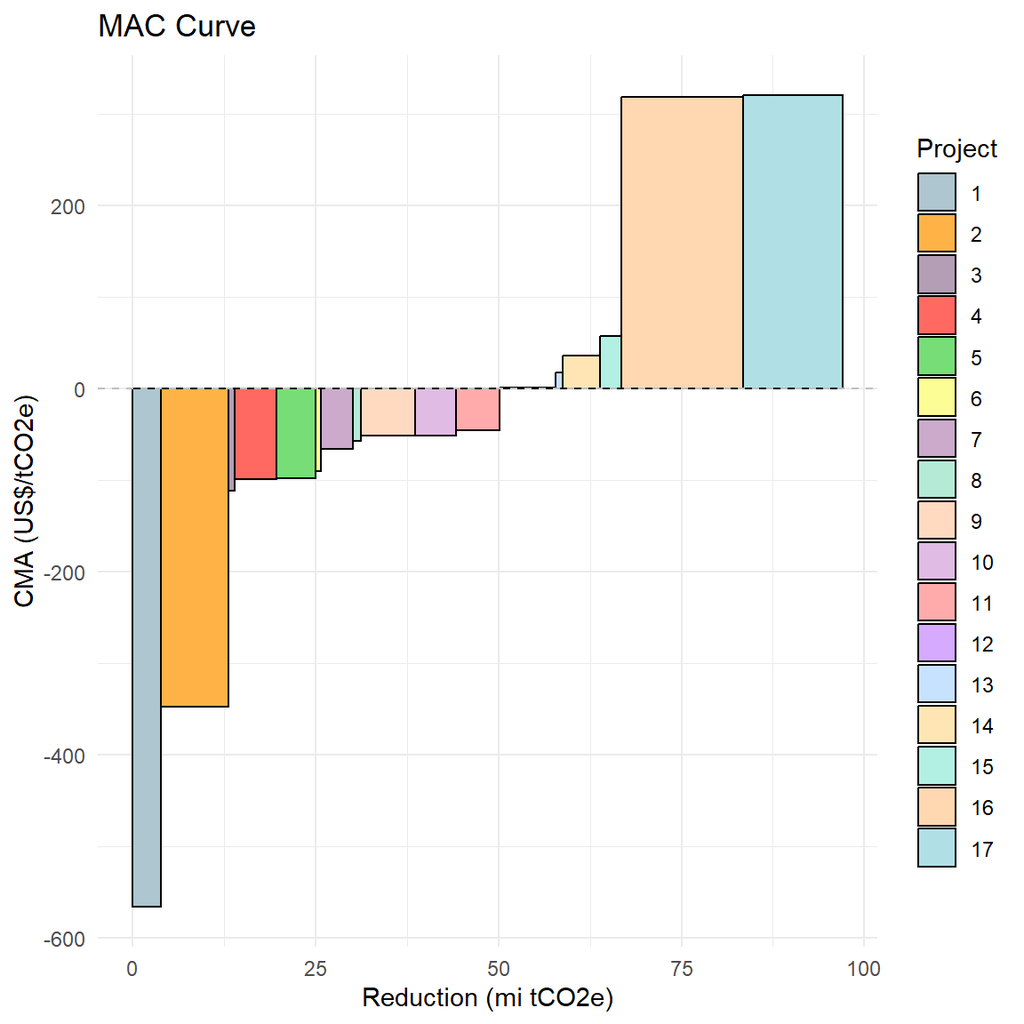

```r
# Packages
library(dplyr)
library(readr)
library(ggplot2)
library(Polychrome)



pastel20 <- c(
  "#AEC6CF", "#FFB347", "#B39EB5", "#FF6961", "#77DD77",
  "#FDFD96", "#CBAACB", "#B5EAD7", "#FFDAC1", "#E0BBE4",
  "#FFABAB", "#D5AAFF", "#C6E2FF", "#FFE5B4", "#B2F0E3",
  "#FFD8B1", "#B0E0E6", "#D6CADD", "#FAF3DD", "#CCE2CB"
)


# import data
data_5 <- read.csv("20250401_Base_Projetos_v1.csv")

# Transform data
data_5_adj <- data_5 %>%
  filter(Id <= 17)
#glimpse(data_5_adj)


data_5_adj <- data_5_adj %>%
  rename(
    Project = Projetos,
    CMA = `CMA..US..tCO2e.`,
    Reduction = `Reducao_GEE..tCO2e.`
  )


# Order by CMA
data_sorted <- data_5_adj %>%
  arrange(CMA) %>%
  mutate(
    X_inicio = lag(cumsum(Reduction), default = 0),
    X_fim = cumsum(Reduction),
    Y_base = 0,
    Y_top = CMA
  )

# Graph
ggplot(data_sorted) +
  geom_rect(
    aes(xmin = X_inicio / 1e6,
        xmax = X_fim / 1e6,
        ymin = Y_base,
        ymax = Y_top,
        fill = as.factor(Id)),
    color = "black"
  ) +
   scale_fill_manual(values = pastel20, name = "Project") +
  labs(
    title = "MAC Curve",
    x = "Reduction (mi tCO2e)",
    y = "CMA (US$/tCO2e)"
  ) +
  theme_minimal() +
  geom_hline(yintercept = 0, linetype = "dashed", color = "gray")
```

The Marginal Abatement Cost Curve (MACC) is widely used to compare and prioritize mitigation options based on their cost-effectiveness (US$/tCO₂e avoided). While the tool is conceptually simple and powerful for visualization and planning, it has significant limitations, particularly in dynamic or volatile economic contexts.

MACC is inherently static, it assumes that costs, emissions reductions, and project parameters remains constant over time. In reality, climate action is dynamic: technologies evolve, costs decrease, risks shift, and new regulations or carbon markets emerge. The MACC does not capture these trajectories.

In geopolitical scenarios such as a potential Trump administration, where U.S. interest rates are expected to rise, global capital markets may react. Brazil and other emerging economies may face pressure to raise their own interest rates to remain competitive. This could drive up the discount rates used in project evaluation, especially for foreign-funded or public-private climate initiatives.

A decarbonization strategy looking mainly on MACC ignores Co-benefits and Non-Monetary Value such as Health benefits from improved air quality, Social equity outcomes, Job creation, Biodiversity protection.These co-benefits can significantly enhance the value of a project but are not reflected in the curve, potentially leading to underinvestment in high-impact solutions.

```r
library(dplyr)
library(readr)
library(plotly)
# Load and prepare data
data <- read_csv("20250401_Base_Projetos_v1.csv") %>%
  rename(
    Project_ID = Id_Projetos,
    Project = Projetos,
    CMA = `CMA (US$/tCO2e)`,
    Reduction = `Reducao_GEE (tCO2e)`,
    Discount = Taxa
  )
# Clean and transform
data <- data %>%
  mutate(
    Discount = as.numeric(gsub("%", "", Discount)),
    Reduction = Reduction / 1e6  # Convert to million tCO2e
  ) %>%
  filter(Project_ID <= 17)

# Get unique discount rates and assign a color to each
discounts <- sort(unique(data$Discount))
colors <- RColorBrewer::brewer.pal(length(discounts), "Set2")
discount_colors <- setNames(colors, discounts)

# Start 3D figure
fig <- plot_ly()

# Loop through each discount rate
for (d in discounts) {
  d_data <- data %>%
    filter(Discount == d) %>%
    arrange(CMA) %>%
    mutate(
      X_start = lag(cumsum(Reduction), default = 0),
      X_end = cumsum(Reduction),
      Y_base = 0,
      Y_top = CMA,
      Z = d
    )

  for (i in 1:nrow(d_data)) {
    row <- d_data[i, ]

    fig <- fig %>% add_trace(
      type = "scatter3d",
      mode = "lines",
      x = c(row$X_start, row$X_end, row$X_end, row$X_start, row$X_start),
      y = c(row$Y_top, row$Y_top, row$Y_base, row$Y_base, row$Y_top),
      z = rep(row$Z, 5),
      line = list(width = 6, color = discount_colors[as.character(row$Z)]),
      name = paste0("Discount ", row$Z, "%"),
      showlegend = FALSE
    )
  }
}

# Layout
fig <- fig %>%
  layout(
    title = "3D MACC",
    scene = list(
      xaxis = list(title = "Reduction (mi tCO2e)"),
      yaxis = list(title = "CMA (US$/tCO2e)"),
      zaxis = list(title = "Discount Rate (%)")
    )
  )

fig
```

[interactive chart not shown]

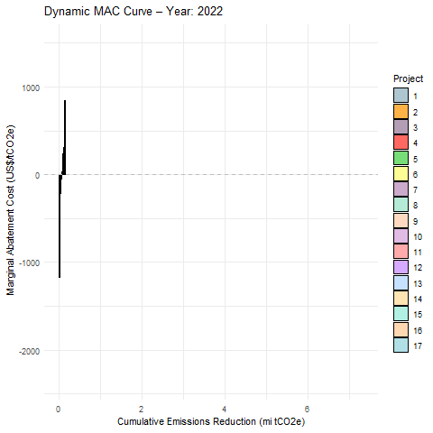

```r
# Load required packages
library(dplyr)
library(ggplot2)
library(gganimate)
library(readr)

# Define pastel color palette (20 fixed project colors)
pastel20 <- c(
  "#AEC6CF", "#FFB347", "#B39EB5", "#FF6961", "#77DD77",
  "#FDFD96", "#CBAACB", "#B5EAD7", "#FFDAC1", "#E0BBE4",
  "#FFABAB", "#D5AAFF", "#C6E2FF", "#FFE5B4", "#B2F0E3",
  "#FFD8B1", "#B0E0E6", "#D6CADD", "#FAF3DD", "#CCE2CB"
)

# Load dataset
data <- read_csv("20250401_Base_Projetos_v2.csv")

# Prepare MAC structure per year
data_mac <- data %>%
  rename(
    CMA = `CMA (USD/tCO2e)`,
    Reduction = `Reducao (tCO2e)`,
    Cost = `FC (USD)`
  ) %>%
  group_by(Ano) %>%
  arrange(CMA, .by_group = TRUE) %>%
  mutate(
    X_start = lag(cumsum(Reduction), default = 0),
    X_end = cumsum(Reduction),
    Project = factor(Id),
    Name = Projetos
  ) %>%
  ungroup()

# Create animated MAC plot
p <- ggplot(data_mac) +
  geom_rect(
    aes(
      xmin = X_start / 1e6,
      xmax = X_end / 1e6,
      ymin = 0,
      ymax = CMA,
      fill = Project
    ),
    color = "black"
  ) +
  scale_fill_manual(values = pastel20, name = "Project") +
  labs(
    title = "Dynamic MAC Curve – Year: {closest_state}",
    x = "Cumulative Emissions Reduction (mi tCO2e)",
    y = "Marginal Abatement Cost (US$/tCO2e)"
  ) +
  theme_minimal() +
  geom_hline(yintercept = 0, linetype = "dashed", color = "gray") +
  transition_states(Ano, transition_length = 2, state_length = 1) +
  ease_aes('linear')

# Render animation with play/pause controls in HTML
anim1 <- animate(p, renderer = gifski_renderer(loop = TRUE))
anim_save("mac_animation1.gif", animation = anim1)
```

[figure not shown]

```r
library(dplyr)
library(ggplot2)
library(gganimate)
library(readr)

# Color palette
pastel20 <- c(
  "#AEC6CF", "#FFB347", "#B39EB5", "#FF6961", "#77DD77",
  "#FDFD96", "#CBAACB", "#B5EAD7", "#FFDAC1", "#E0BBE4",
  "#FFABAB", "#D5AAFF", "#C6E2FF", "#FFE5B4", "#B2F0E3",
  "#FFD8B1", "#B0E0E6", "#D6CADD", "#FAF3DD", "#CCE2CB"
)

# Load data with columns: Id, Projetos, Ano, CMA, Reducao (year-specific!)
data <- read_csv("20250401_Base_Projetos_v2.csv")

# Prepare the MAC year by year (no accumulation across years)
mac_per_year <- data %>%
  rename(
    CMA = `CMA (USD/tCO2e)`,
    Reduction = `Reducao (tCO2e)`
  ) %>%
  group_by(Ano) %>%
  arrange(CMA, .by_group = TRUE) %>%
  mutate(
    X_inicio = lag(cumsum(Reduction), default = 0),
    X_fim = cumsum(Reduction),
    Project = factor(Id)
  ) %>%
  ungroup()

# MAC Animation (snapshot per year)
p <- ggplot(mac_per_year) +
  geom_rect(
    aes(xmin = X_inicio / 1e6,
        xmax = X_fim / 1e6,
        ymin = 0,
        ymax = CMA,
        fill = Project),
    color = "black"
  ) +
  scale_fill_manual(values = pastel20, name = "Project") +
  labs(
    title = "MAC Curve – Year: {closest_state}",
    x = "Emission Reduction (mi tCO2e)",
    y = "Marginal Abatement Cost (US$/tCO2e)"
  ) +
  theme_minimal() +
  geom_hline(yintercept = 0, linetype = "dashed", color = "gray") +
  transition_states(Ano, transition_length = 2, state_length = 1) +
  ease_aes('linear')+
  view_follow(fixed_y = TRUE)

# Save or animate
anim2 <- animate(p, nframes = 80, fps = 3, width = 800, height = 500, renderer = gifski_renderer())
anim_save("mac_animation.gif", animation = anim2)
```

## MDCA

Multi-Criteria Decision Analysis (MCDA) is a structured decision-making approach used to evaluate and rank multiple alternatives based on several conflicting criteria. It is especially valuable when decisions involve trade-offs between economic, environmental, technical, and social dimensions.

Unlike single-criterion methods (like cost-benefit analysis), MCDA acknowledges that real-world decisions are multi-dimensional and cannot be reduced to a single metric.

The most widely used MCDA model is the linear additive model, where the composite score of an alternative is computed as:

$$\begin{align*}
\text{Score}_i = \sum_{j=1}^{n} w_j \cdot x_{ij}^{\text{norm}}
\end{align*}$$

Where:

- $i$ = alternative (e.g., a project)
- $j$ = criterion (e.g., cost, risk)
- $w_j$ = normalized weight for criterion $j$, such that:

$$\sum_{j=1}^{n} w_j = 1$$

- $x_{ij}^{\text{norm}}$ = normalized score of alternative $i$ on criterion $j$

### Normalization

Because criteria are measured on different scales (e.g., US$/tCO2e, scores from 0–10), they must be normalized.

#### For Positive Criteria (the higher, the better):

$$x_{ij}^{\text{norm}} = \frac{x_{ij} - \min(x_j)}{\max(x_j) - \min(x_j)}$$

#### For Negative Criteria (the lower, the better):

$$x_{ij}^{\text{norm}} = 1 - \frac{x_{ij} - \min(x_j)}{\max(x_j) -
\min(x_j)}$$

```r
# Load required packages
library(tidyverse)
library(scales)
#Import data
df <- read.csv("20250404_MDCA_Ex1.csv", encoding = "UTF-8")

#Rename columns for consistency
df <- df %>%
  rename(
    Cost = CMA,
    CoBenefits = CoBeneficios_Score,
    TechFeasibility = Viabilidade_Tecnica,
    RegFeasibility = Viabilidade_Regulatoria,
    RiskFinancial = Risco_Financeiro,
    RiskImplementation = Risco_Implementacao,
    EmissionReduction = Reducao
  )


#Create a table
datatable(df , options = list(
  pageLength = 6,
  autoWidth = TRUE,
  columnDefs = list(list(width = '150px', targets = "_all"))
), caption = "Dataset")
```

|  | Id | Projeto | Cost | EmissionReduction | VPL | CoBenefits | TechFeasibility | RegFeasibility | RiskFinancial | RiskImplementation |
| --- | --- | --- | --- | --- | --- | --- | --- | --- | --- | --- |
| 1 | 1 | Projeto 1 | -565.82 | 3876399.32 | 2193327457 | 4 | 9 | 10 | 2 | 2 |
| 2 | 2 | Projeto 2 | -347.21 | 9183062.6 | 3188447823 | 5 | 8 | 9 | 3 | 3 |
| 3 | 3 | Projeto 3 | -112 | 828082.23 | 92747377.39 | 6 | 8 | 8 | 3 | 3 |
| 4 | 4 | Projeto 4 | -99.01 | 5772365.05 | 571514541.6 | 6 | 9 | 10 | 2 | 2 |
| 5 | 5 | Projeto 5 | -98.3 | 5313235.79 | 522296001 | 9 | 4 | 5 | 8 | 8 |
| 6 | 6 | Projeto 6 | -90.84 | 703249.48 | 63883522.49 | 5 | 7 | 9 | 4 | 4 |
| 7 | 7 | Projeto 7 | -65.93 | 4427696.49 | 291937952.2 | 8 | 5 | 6 | 7 | 7 |
| 8 | 8 | Projeto 8 | -57.4 | 1101756.09 | 63237733.81 | 6 | 6 | 8 | 6 | 6 |
| 9 | 9 | Projeto 9 | -52.08 | 7373223.41 | 384019170.6 | 7 | 5 | 6 | 6 | 6 |
| 10 | 10 | Projeto 10 | -51.45 | 5649706.76 | 290666840.8 | 4 | 9 | 10 | 2 | 2 |

[output cut: 7 more lines]

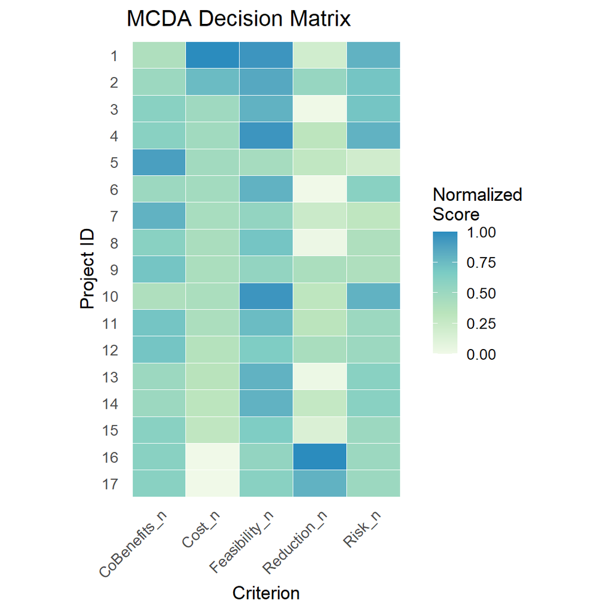

```r
#Normalize criteria (0 to 1)
df <- df %>%
  mutate(
    Cost_n = 1 - (Cost - min(Cost)) / (max(Cost) - min(Cost)),
    CoBenefits_n = CoBenefits / 10,
    Feasibility_n = (TechFeasibility + RegFeasibility) / 20,
    Risk_n = 1 - ((RiskFinancial + RiskImplementation) / 20),
    Reduction_n = (EmissionReduction - min(EmissionReduction)) /
                             (max(EmissionReduction) - min(EmissionReduction))
  )

#Define weights for each criterion (sum = 1)
w_cost <- 0.20
w_cobenef <- 0.20
w_feas <- 0.20
w_risk <- 0.20
w_emission <- 0.20

#Compute MCDA Total Score
df <- df %>%
  mutate(
    MCDA_Score = w_cost * Cost_n +
                 w_cobenef * CoBenefits_n +
                 w_feas * Feasibility_n +
                 w_risk * Risk_n +
                 w_emission * Reduction_n
  ) %>%
  arrange(desc(MCDA_Score))

#Create Decision Matrix (Heatmap style with pastel colors)
matrix_df <- df %>%
  select(Id, Cost_n, CoBenefits_n, Feasibility_n, Risk_n, Reduction_n) %>%
  pivot_longer(cols = -Id, names_to = "Criterion", values_to = "Score")

ggplot(matrix_df, aes(x = Criterion, y = reorder(Id, desc(Id)), fill = Score)) +
  geom_tile(color = "white") +
  scale_fill_gradientn(colors = c("#f0f9e8", "#bae4bc", "#7bccc4", "#2b8cbe")) +
  labs(title = "MCDA Decision Matrix",
       x = "Criterion", y = "Project ID", fill = "Normalized\nScore") +
  theme_minimal(base_size = 13) +
  theme(axis.text.x = element_text(angle = 45, hjust = 1),
        panel.grid = element_blank())+coord_fixed(ratio = 0.5)
```

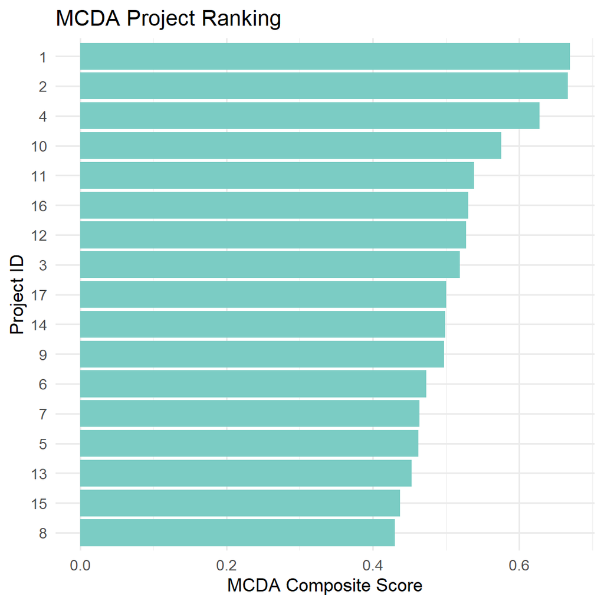

```r
#Create Ranking Bar Chart
ggplot(df, aes(x = reorder(Id, MCDA_Score), y = MCDA_Score)) +
  geom_col(fill = "#7bccc4") +
  coord_flip() +
  labs(title = "MCDA Project Ranking",
       x = "Project ID", y = "MCDA Composite Score") +
  theme_minimal(base_size = 13)
```

## Feasibility Analysis

Feasibility Analysis provides a structured assessment of the practicality and implementability of decarbonization projects. It evaluates each initiative across multiple dimensions that influence its likelihood of success in real-world settings. The dataset includes the following key parameters: **TRL** (Technology Readiness Level), ranging from 1 to 9, reflects the maturity of the technology involved. **CAPEX** indicates the initial capital expenditure required to implement the project. **Permitting Barriers** captures potential regulatory or permitting barriers, categorized as Low, Medium, or High. **Regulatory Alignment** assesses the project’s alignment with existing public policies and climate frameworks. **Implementation Time** represents the estimated time needed for implementation, in months. **Scalability** indicates whether the project is scalable or replicable across other sites or sectors. Finally, **Technical Feasibility** provides a subjective technical feasibility rating, typically based on expert judgment. Together, these criteria offer a comprehensive view of each project’s feasibility, supporting strategic planning and investment decision-making.

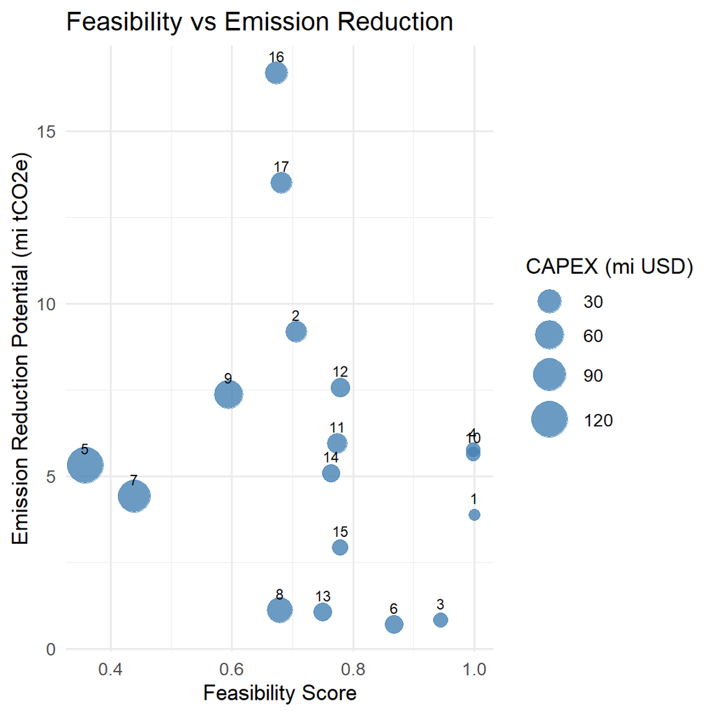

```r
# Load packages
library(tidyverse)
library(scales)

# Load data
df <- read.csv("20250404_FS_Ex1.csv", encoding = "UTF-8")

# Normalize and score columns
df <- df %>%
  mutate(
    Reducao_mi = Reducao / 1e6,
    TRL_score = TRL / 9,
    CAPEX_n = 1 - (CAPEX - min(CAPEX, na.rm = TRUE)) /
                       (max(CAPEX, na.rm = TRUE) - min(CAPEX, na.rm = TRUE)),
    Licenciamento_score = case_when(
      Licenciamento == "Baixo" ~ 1,
      Licenciamento == "Medio" ~ 0.5,
      Licenciamento == "Alto" ~ 0,
      TRUE ~ NA_real_
    ),
    Alinhamento_score = case_when(
      Alinhamento_Reg == "Total" ~ 1,
      Alinhamento_Reg == "Parcial" ~ 0.5,
      Alinhamento_Reg == "Nenhum" ~ 0,
      TRUE ~ NA_real_
    ),
    Tempo_n = 1 - (Tempo_Impl - min(Tempo_Impl, na.rm = TRUE)) /
                       (max(Tempo_Impl, na.rm = TRUE) - min(Tempo_Impl, na.rm = TRUE)),
    Escalavel_score = case_when(
      Escalavel == "Sim" ~ 1,
      Escalavel == "Não" ~ 0,
      TRUE ~ NA_real_
    )
  )

# Define weights
w_trl <- 0.2
w_capex <- 0.2
w_lic <- 0.15
w_alinh <- 0.15
w_tempo <- 0.15
w_escal <- 0.15

# Compute Feasibility Score
df <- df %>%
  mutate(
    Feasibility_Score = w_trl * TRL_score +
                        w_capex * CAPEX_n +
                        w_lic * Licenciamento_score +
                        w_alinh * Alinhamento_score +
                        w_tempo * Tempo_n +
                        w_escal * Escalavel_score
  ) %>%
  arrange(desc(Feasibility_Score))

# PLOT 1: Bubble Chart

ggplot(df, aes(x = Feasibility_Score, y = Reducao_mi,
               size = CAPEX, label = Id)) +
  geom_point(alpha = 0.8, color = "#4682b4") +  # Azul pastel fixo
  geom_text(size = 3, vjust = -1, color = "black") +
  scale_size_continuous(name = "CAPEX (mi USD)", range = c(3, 10)) +
  labs(title = "Feasibility vs Emission Reduction ",
       x = "Feasibility Score",
       y = "Emission Reduction Potential (mi tCO2e)") +
  theme_minimal(base_size = 13)
```